# Descriptive Statistics with Python and R

## Index

- Data-set
- - Working with `Python`
- - Working with `R`
- Data-set Description
- Statistical Variable
- Data Martrix
- - Data Martrix Representation by Rows
- - Data Martrix Representation by Columns
- Range of a Statistical Variable
- Types of Statistical Variable
- - Types of Quantitative Variables
- - - Discrete and Continuous Variables
- - Types of Categorical Variables
- - - Nominal and Ordinal Variables
- Descriptive Statistic
- - Mean
- - - Mean Vector
- - - Matrix Expression of the Mean Vector
- - Ponderate Mean
- - Geometric Mean
- - Median
- - Quantiles
- - Variance and Standard Deviation
- Basic descriptive summary in `Python`
- Basic descriptive summary in `R`
- Centered Data Matrix
- Scaled Variables
- Scaled Data Matrix
- Covariance
- - Properties of covariance
- Covariance Matrix
- Pearson Linear Correlation
- - Properties of Pearson linear correlation
- Pearson Correlation Matrix
- Frequency Distribution
- - Absolute frequency of an element
- - Absolute frequency of a set
- - Relative frequency of an element
- - Relative frequency of a set
- - Cumulative Frequencies
- Frequency Table
- - Frequency Table in `Python`
- - Frequency Table in `R`
- - Categorization of Quantitative Variables
- - - Median Rule
- - - Mean Rule
- - - Quartile Rule
- - - Scott's Rule
- - - Modified Scott's Rule
- Histogram
- Bar Plot
- Box-plot
- Skewness and Kurtosis
- - Skewness Coefficient
- - - Skewness coefficient properties
- - Kurtosis Coefficient
- - - Kurtosis Coefficient properties

## Data-Set

We load the data-set with which we are going to work mainly:

### Working with `Python`

```python
import pandas as pd
import numpy as np

from IPython.display import display
pd.options.display.max_columns = None

import warnings
warnings.filterwarnings('ignore')
```

We load the data-set that we will use in this article using the following link:

https://raw.githubusercontent.com/FabioScielzoOrtiz/Estadistica4all-blog/main/Descriptive%20Statisitcs%20in%20Python%20and%20R/datosAragon.csv

```python
url = 'https://raw.githubusercontent.com/FabioScielzoOrtiz/Estadistica4all-blog/main/Descriptive%20Statisitcs%20in%20Python%20and%20R/datosAragon.csv'

data_Python = pd.read_csv(url)

data_Python
```

|  | ca | datosECVmas16.prov | nomprov | gen | edad | nac | neduc | sitlab | ingnorm | horas | factorel |
| --- | --- | --- | --- | --- | --- | --- | --- | --- | --- | --- | --- |
| 0 | 2 | 22 | Huesca | 1 | 3 | 1 | 3 | 1 | 21237.1 | 36.42 | 393.7 |
| 1 | 2 | 22 | Huesca | 2 | 2 | 1 | 2 | 1 | 17810.8 | 31.72 | 393.7 |
| 2 | 2 | 22 | Huesca | 1 | 1 | 1 | 2 | 1 | 11889.1 | 31.88 | 393.7 |
| 3 | 2 | 22 | Huesca | 1 | 1 | 1 | 2 | 1 | 16000.5 | 38.18 | 393.7 |
| 4 | 2 | 22 | Huesca | 1 | 1 | 1 | 2 | 3 | 21169.6 | 0.00 | 393.7 |
| ... | ... | ... | ... | ... | ... | ... | ... | ... | ... | ... | ... |
| 1231 | 2 | 50 | Zaragoza | 1 | 2 | 1 | 2 | 1 | 11760.6 | 28.79 | 2206.1 |
| 1232 | 2 | 50 | Zaragoza | 1 | 2 | 1 | 2 | 2 | 19321.6 | 0.00 | 124.4 |
| 1233 | 2 | 50 | Zaragoza | 2 | 2 | 1 | 2 | 1 | 19924.8 | 37.21 | 124.4 |
| 1234 | 2 | 50 | Zaragoza | 2 | 3 | 1 | 1 | 3 | 13042.5 | 0.00 | 246.5 |
| 1235 | 2 | 50 | Zaragoza | 1 | 3 | 1 | 1 | 1 | 19618.2 | 42.01 | 246.5 |

1236 rows × 11 columns

Throughout this article we will use the Python package `dfply`

```python
# pip install dfply

from dfply import *
```

We prepare the data-set:

We select the columns that we will use:

```python
data_Python = (data_Python.T >> row_slice( list(range(2,10)) ) ).T

data_Python
```

|  | nomprov | gen | edad | nac | neduc | sitlab | ingnorm | horas |
| --- | --- | --- | --- | --- | --- | --- | --- | --- |
| 0 | Huesca | 1 | 3 | 1 | 3 | 1 | 21237.1 | 36.42 |
| 1 | Huesca | 2 | 2 | 1 | 2 | 1 | 17810.8 | 31.72 |
| 2 | Huesca | 1 | 1 | 1 | 2 | 1 | 11889.1 | 31.88 |
| 3 | Huesca | 1 | 1 | 1 | 2 | 1 | 16000.5 | 38.18 |
| 4 | Huesca | 1 | 1 | 1 | 2 | 3 | 21169.6 | 0.0 |
| ... | ... | ... | ... | ... | ... | ... | ... | ... |
| 1231 | Zaragoza | 1 | 2 | 1 | 2 | 1 | 11760.6 | 28.79 |
| 1232 | Zaragoza | 1 | 2 | 1 | 2 | 2 | 19321.6 | 0.0 |
| 1233 | Zaragoza | 2 | 2 | 1 | 2 | 1 | 19924.8 | 37.21 |
| 1234 | Zaragoza | 2 | 3 | 1 | 1 | 3 | 13042.5 | 0.0 |
| 1235 | Zaragoza | 1 | 3 | 1 | 1 | 1 | 19618.2 | 42.01 |

1236 rows × 8 columns

We rename some of these columns:

```python
data_Python = data_Python >> rename( genero=X.gen ,
                              provincia=X.nomprov ,
                              ingresos=X.ingnorm )

data_Python
```

|  | provincia | genero | edad | nac | neduc | sitlab | ingresos | horas |
| --- | --- | --- | --- | --- | --- | --- | --- | --- |
| 0 | Huesca | 1 | 3 | 1 | 3 | 1 | 21237.1 | 36.42 |
| 1 | Huesca | 2 | 2 | 1 | 2 | 1 | 17810.8 | 31.72 |
| 2 | Huesca | 1 | 1 | 1 | 2 | 1 | 11889.1 | 31.88 |
| 3 | Huesca | 1 | 1 | 1 | 2 | 1 | 16000.5 | 38.18 |
| 4 | Huesca | 1 | 1 | 1 | 2 | 3 | 21169.6 | 0.0 |
| ... | ... | ... | ... | ... | ... | ... | ... | ... |
| 1231 | Zaragoza | 1 | 2 | 1 | 2 | 1 | 11760.6 | 28.79 |
| 1232 | Zaragoza | 1 | 2 | 1 | 2 | 2 | 19321.6 | 0.0 |
| 1233 | Zaragoza | 2 | 2 | 1 | 2 | 1 | 19924.8 | 37.21 |
| 1234 | Zaragoza | 2 | 3 | 1 | 1 | 3 | 13042.5 | 0.0 |
| 1235 | Zaragoza | 1 | 3 | 1 | 1 | 1 | 19618.2 | 42.01 |

1236 rows × 8 columns

We can see the structure of the variables of our data-set:

```python
data_Python.dtypes
```

```
provincia    object
genero       object
edad         object
nac          object
neduc        object
sitlab       object
ingresos     object
horas        object
dtype: object
```

We will convert the structure of them in the following way:

```python
data_Python['ingresos'] = data_Python['ingresos'].astype(float)
data_Python['horas'] = data_Python['horas'].astype(float)

data_Python['genero'] = data_Python['genero'].astype('category')
data_Python['edad'] = data_Python['edad'].astype('category')
data_Python['nac'] = data_Python['nac'].astype('category')
data_Python['neduc'] = data_Python['neduc'].astype('category')
data_Python['sitlab'] = data_Python['sitlab'].astype('category')
data_Python['provincia'] = data_Python['provincia'].astype('category')
```

Now we check if changes have been done correctly:

```python
data_Python.dtypes
```

```
provincia    category
genero       category
edad         category
nac          category
neduc        category
sitlab       category
ingresos      float64
horas         float64
dtype: object
```

```python
data_Python
```

|  | provincia | genero | edad | nac | neduc | sitlab | ingresos | horas |
| --- | --- | --- | --- | --- | --- | --- | --- | --- |
| 0 | Huesca | 1 | 3 | 1 | 3 | 1 | 21237.1 | 36.42 |
| 1 | Huesca | 2 | 2 | 1 | 2 | 1 | 17810.8 | 31.72 |
| 2 | Huesca | 1 | 1 | 1 | 2 | 1 | 11889.1 | 31.88 |
| 3 | Huesca | 1 | 1 | 1 | 2 | 1 | 16000.5 | 38.18 |
| 4 | Huesca | 1 | 1 | 1 | 2 | 3 | 21169.6 | 0.00 |
| ... | ... | ... | ... | ... | ... | ... | ... | ... |
| 1231 | Zaragoza | 1 | 2 | 1 | 2 | 1 | 11760.6 | 28.79 |
| 1232 | Zaragoza | 1 | 2 | 1 | 2 | 2 | 19321.6 | 0.00 |
| 1233 | Zaragoza | 2 | 2 | 1 | 2 | 1 | 19924.8 | 37.21 |
| 1234 | Zaragoza | 2 | 3 | 1 | 1 | 3 | 13042.5 | 0.00 |
| 1235 | Zaragoza | 1 | 3 | 1 | 1 | 1 | 19618.2 | 42.01 |

1236 rows × 8 columns

### Working with `R`

To work with R inside Python we will use the Python package `rpy2`

```python
# pip install rpy2

import rpy2

%load_ext rpy2.ipython

import rpy2.robjects as robjects
```

```
The rpy2.ipython extension is already loaded. To reload it, use:
  %reload_ext rpy2.ipython
```

We prepare the data-set:

```python
%%R

library(tidyverse)

url = 'https://raw.githubusercontent.com/FabioScielzoOrtiz/Estadistica4all-blog/main/Descriptive%20Statisitcs%20in%20Python%20and%20R/datosAragon.csv'

data_R <- read_csv(url)

data_R <- data_R %>% select(3:10)

data_R <- data_R %>% rename("genero"="gen",
         "provincia"="nomprov", "ingresos"="ingnorm")

data_R <- as.data.frame(data_R)
```

```python
%%R

head(data_R)
```

```
  provincia genero edad nac neduc sitlab ingresos horas
1    Huesca      1    3   1     3      1  21237.1 36.42
2    Huesca      2    2   1     2      1  17810.8 31.72
3    Huesca      1    1   1     2      1  11889.1 31.88
4    Huesca      1    1   1     2      1  16000.5 38.18
5    Huesca      1    1   1     2      3  21169.6  0.00
6    Huesca      1    2   1     2      1  16001.3 34.52
```

## Data-set Description

The definition of the variables are the following:

- **provincia**: indicates the province of the Aragon community which belong the sample individuals.
- **genero**: indicates the sex of the sample individuals. Take 1 if it's male and 2 if it's female.
- **edad**: indicates the age range of the sample individuals. Take 1 if age is between 16 and 24 ages, 2 if age is between 25 and 49 ages, and 3 if age is between 50 and 64 ages, and 4 if age is greater or equal than 65 ages.
- **nacionalidad** (**nac**): indicates the nacionality of the sample individuals. If they are from Spain, it takes 1, and if they are from other country, it takes 2.
- **situacion laboral** (**sitlab**): indicates the labor situation of the sample individuals. It takes 1 if they are working, 2 if they are unemployed, and 3 if they are inactive.
- **ingresos** : indicates the incomes of the individuals in the sample.
- **horas** : indicates the number of working hours of the individuals in the sample.
- **neduc** : indicates the education level of the individuals in the sample. It takes 1 if they have low education level, 2 if they have intermediate education level, and 3 if they have high education level.

## Statistical Variable

$$ X_k= \begin{pmatrix} x_{1k} \\ x_{2k}\\ ... \\ x_{nk} \end{pmatrix} $$

is a **statistical variable** because is a vector with the values or observations of variable $X_k$ for $n$ elements or individuals of a sample.

Where: $x_{ik}$ is the value or observation of $X_k$ variable for the $i$ element of the sample.

## Data Martrix

In general, if we have observed $p$ variables on a sample $\varepsilon$ with $n$ elements/individuals ,

The data matrix $X$ of the variables $X_1,...,X_p$ measurements on the sample is:

$$ X= \begin{pmatrix} x_{11} & x_{12}&...&x_{1p}\\ x_{21} & x_{22}&...&x_{2p}\\ ...&...&...&...\\ x_{n1}& x_{n2}&...&x_{np} \end{pmatrix} $$

Note: $X$ is a matrix $nxp$

### Data Martrix Representation by Rows

$$ X= \begin{pmatrix} x_{1}^{t} \\ x_{2} ^t \\ ... \\ x_{n} ^t \end{pmatrix} $$

Where:

$x_i ^t = (x_{i1}, x_{i2}, ..., x_{ip} )$ is the vector with the values of the $p$ variables $X_1,...,X_p$ for the $i$ element/individual of the sample, for $i=1,...,n$

### Data Martrix Representation by Columns

We can express:

$$ X= (X_1 , X_2 ,..., X_p ) $$

Where: $$ X_k= \begin{pmatrix} x_{1k} \\ x_{2k}\\ ... \\ x_{nk} \end{pmatrix} $$

for $k=1,2,...,p$

## Range of a Statistical Variable

The **range** of a statistical variable $X_k$ is the set of values that can be taken by the variable.

Depending on the variable range we can define if the variable is **quantitative** or **categorical** . Clasification that has a particular relevance in statistics.

Examples:

$X_k =$ Incomes of 1000 employees of Amazon $\Rightarrow$ $Range(X_k) =[0, \infty )$

$X_k =$ brand of the car of 50 footballers $\Rightarrow$ $Range(X_k) = \lbrace Mercedes, Audi, ... \rbrace$

$X_k =$ Number of houses of 10 urbanizations $\Rightarrow$ $Range(X_k) = \lbrace 0, 1, 2,... \rbrace$

## Types of Statistical Variable

The variable $X_k$ is **quantitative** if the elements of it´s range are conceptually numbers.

The variable $X_k$ is **categorical** if the elements of it´s range aree labels or categories (they can be numbers at a symbolic level but not at a conceptual level)

### Types of Quantitative Variables

#### Discrete and Continuous Variables

Let $X_k$ a **quantitative** variable ,

The variable $X_k$ is **discrete** if it´s range is a numerable set .

The variable $X_k$ is **continuous** if it´s range isn´t a numerable set.

**Note:**

In particular, variables whose **range** is a **finite** set will be **discrete**.

variables whose **range** isn´t a **finite** set will be **continuous**.

### Types of Categorical Variables

Let $X_k$ a **categorical** variable ,

$X_k$ is **r-aria** if it´s range has **r** elements that are categories or labels.

In Statistics **binary** (2-aria) categorical variables are particularly important.

#### Nominal and Ordinal Variables

Let $X_k$ a $r$-aria **categorical** variable ,

The variable $X_k$ is **nominal** if **there is no ordering** between the $r$ categories of it´s range.

The variable $X_k$ is **ordinal** if **there is ordering** between the $r$ categories of it´s range.

**Examples:**

$Range(X_k)= \lbrace Apple , Samsung, Oppo \rbrace \Rightarrow X_k$ is nominal

$Range(X_k)= \lbrace mal , regular, bien \rbrace \Rightarrow X_k$ is ordinal

## Descriptive Statistic

A descriptive statistic is a function of a sample elements.

In general, all function applied on a statistical variable is a statistic.

We will see some of most important statistics.

### Mean

The arithmetic mean (or simply mean) of a variable $X_k$ is defined as:

$$ \overline{X_k}= \frac{1}{n} \cdot \sum_{i=1}^{n} x_{ik} $$

**Some Properties:**

$$ \sum_{i=1}^{n} \left( x_{ik} - \overline{X_k} \right) = 0 $$

#### Mean in R

```python
%%R
head(data_R)
```

```
  provincia genero edad nac neduc sitlab ingresos horas
1    Huesca      1    3   1     3      1  21237.1 36.42
2    Huesca      2    2   1     2      1  17810.8 31.72
3    Huesca      1    1   1     2      1  11889.1 31.88
4    Huesca      1    1   1     2      1  16000.5 38.18
5    Huesca      1    1   1     2      3  21169.6  0.00
6    Huesca      1    2   1     2      1  16001.3 34.52
```

One way to compute the mean of a variable in R:

```python
%%R
mean(data_R$ingresos)
```

```
[1] 14078.77
```

#### Mean in Python

```python
data_Python >> head()
```

|  | provincia | genero | edad | nac | neduc | sitlab | ingresos | horas |
| --- | --- | --- | --- | --- | --- | --- | --- | --- |
| 0 | Huesca | 1 | 3 | 1 | 3 | 1 | 21237.1 | 36.42 |
| 1 | Huesca | 2 | 2 | 1 | 2 | 1 | 17810.8 | 31.72 |
| 2 | Huesca | 1 | 1 | 1 | 2 | 1 | 11889.1 | 31.88 |
| 3 | Huesca | 1 | 1 | 1 | 2 | 1 | 16000.5 | 38.18 |
| 4 | Huesca | 1 | 1 | 1 | 2 | 3 | 21169.6 | 0.00 |

One way to compute the mean of a variable in Python:

```python
data_Python[['ingresos']].mean()
```

```
ingresos    14078.766909
dtype: float64
```

Another way:

```python
( data_Python >> select(X.ingresos) ).mean()
```

```
ingresos    14078.766909
dtype: float64
```

### Mean Vector

Given a data matrix $X$ of size $nxp$,

The means vector of $X$ is:

$$ \overline{X}=( \overline{X_1} , \overline{X_2} , ... , \overline{X_p} ) ^t $$

#### Mean Vector in Python

We can also compute the mean of each variable of a data-set in a easy way:

```python
data_Python.mean()
```

```
ingresos    14078.766909
horas          16.922532
dtype: float64
```

#### Mean Vector in R

```python
%%R

colMeans(data_R[ , 2:length(data_R)])
```

```
      genero         edad          nac        neduc       sitlab     ingresos
    1.502427     2.555016     1.046117     1.805016     1.978155 14078.766909
       horas
   16.922532
```

### Matrix Expression of the Mean Vector

The matrix expression of means vector of $X$ is:

$$ \overline{X}= \dfrac{1}{n} \cdot X\hspace{0.05cm}^t \cdot \overrightarrow{1}_{nx1} $$

### Ponderate Mean

Given the variable $X_k=(x_{1k}, x_{2k},...,x_{nk})^t$

Given a weights for each observation of the variable $X_k$ : $w=(w_1,w_2,...,w_n)^t$

The **weighted mean** de la variable $X_k$ con el vector de pesos $w$ es: $$ \overline{X_k} (w) = \dfrac{\sum_{i=1}^{n} x_{ik}\cdot w_i }{ \sum_{i=1}^{n} w_{i} } $$

### Geometric Mean

Given the variable $X_k=(x_{1k}, x_{2k},...,x_{nk})^t$

The **geometric mean** of the variable $X_k$ is:

$$ \overline{X_k}_{geom} = \sqrt{\Pi_{i=1}^{n} x_{ik}} = \sqrt{x_{1k}\cdot x_{2k}\cdot...\cdot x_{nk}} $$

### Median

The **median** of a variable $X_k$ is a values such that half of the observations of $X_k$ are **less** than that value.

Given the variable $X_k=(x_{1k}, x_{2k},...,x_{nk})^t$

We order their values from smallest to largest:

$x_{(1)k} < x_{(2)k} < ...< x_{(n)k}$

The median of the variable $X_k$ is:

$$ Median(X_k)= \left\lbrace\begin{array}{l} \dfrac{ x_{(n/2)k} + x_{(n/2 + 1)k} }{2} \hspace{0.3cm},\text{ if $n$ is {pair}} \\ x_{(\lceil n/2 \rceil)k} \hspace{0.3cm},\text{ if $n$ is {odd} } \end{array}\right. $$

#### Median in R

```python
%%R

median(data_R$ingresos)
```

```
[1] 12331
```

It can be verified that it is fulfilled the median definition:

```python
%%R

sum(data_R$ingresos < median(data_R$ingresos))/length(data_R$ingresos)
```

```
[1] 0.5
```

#### Median in Python

```python
( data_Python >> select(X.ingresos) ).median()
```

```
ingresos    12331.0
dtype: float64
```

```python
data_Python[['ingresos']].median()
```

```
ingresos    12331.0
dtype: float64
```

```python
data_Python[['ingresos']] < data_Python[['ingresos']].median()
```

|  | ingresos |
| --- | --- |
| 0 | False |
| 1 | False |
| 2 | True |
| 3 | False |
| 4 | False |
| ... | ... |
| 1231 | True |
| 1232 | False |
| 1233 | False |
| 1234 | False |
| 1235 | False |

1236 rows × 1 columns

As in R, we can verify that it is fulfilled the median definition:

```python
( data_Python[['ingresos']] < data_Python[['ingresos']].median() ).sum() / len(data_Python)
```

```
ingresos    0.5
dtype: float64
```

### Quantiles

The quantile of order $p$ of the variable $X_k$ is the value $Q(p, X_k)$ such that the proportion of observations of $X_k$ that are less than $Q(p, X_k)$ is $p$

More formally:

$\hspace{4cm} Q(p, X_k)$ is the quantile of order $p$ of $X_k$ $\Leftrightarrow$ $\hspace{0.3cm} \dfrac{\# \lbrace \hspace{0.05cm} i=1,..,n \hspace{0.15cm} / \hspace{0.15cm} x_{ik} < Q(p, X_k) \hspace{0.05cm} \rbrace}{n}\hspace{0.1cm} = \hspace{0.1cm} p $

Note: the median is the quantile of order $\hspace{0.1cm} p=0.5$

#### Quantiles in R

```python
%%R

quantile(data_R$ingresos)
```

```
      0%      25%      50%      75%     100%
 -999.50  8310.60 12331.00 18269.38 58470.40
```

```python
%%R

quantile(data_R$ingresos, 0.85)
```

```
    85%
21840.8
```

```python
%%R

quantile(data_R$ingresos, 0.37)
```

```
     37%
10329.74
```

#### Quantiles in Python

```python
data_Python
```

|  | provincia | genero | edad | nac | neduc | sitlab | ingresos | horas |
| --- | --- | --- | --- | --- | --- | --- | --- | --- |
| 0 | Huesca | 1 | 3 | 1 | 3 | 1 | 21237.1 | 36.42 |
| 1 | Huesca | 2 | 2 | 1 | 2 | 1 | 17810.8 | 31.72 |
| 2 | Huesca | 1 | 1 | 1 | 2 | 1 | 11889.1 | 31.88 |
| 3 | Huesca | 1 | 1 | 1 | 2 | 1 | 16000.5 | 38.18 |
| 4 | Huesca | 1 | 1 | 1 | 2 | 3 | 21169.6 | 0.00 |
| ... | ... | ... | ... | ... | ... | ... | ... | ... |
| 1231 | Zaragoza | 1 | 2 | 1 | 2 | 1 | 11760.6 | 28.79 |
| 1232 | Zaragoza | 1 | 2 | 1 | 2 | 2 | 19321.6 | 0.00 |
| 1233 | Zaragoza | 2 | 2 | 1 | 2 | 1 | 19924.8 | 37.21 |
| 1234 | Zaragoza | 2 | 3 | 1 | 1 | 3 | 13042.5 | 0.00 |
| 1235 | Zaragoza | 1 | 3 | 1 | 1 | 1 | 19618.2 | 42.01 |

1236 rows × 8 columns

```python
np.quantile( data_Python[['ingresos']] , [0, 0.25, 0.5, 0.75 , 1])
```

```
array([ -999.5  ,  8310.6  , 12331.   , 18269.375, 58470.4  ])
```

```python
np.quantile( data_Python[['ingresos']] , 0.37)
```

```
10329.735
```

```python
np.quantile( data_Python[['ingresos']] , 0.85)
```

```
21840.800000000003
```

We can create a data-frame with the main quantiles of the cuantitative variables ingresos and horas:

```python
a = np.quantile( data_Python[['ingresos']] , [0, 0.25, 0.5, 0.75 , 1])
b = np.quantile( data_Python[['horas']] , [0, 0.25, 0.5, 0.75 , 1])

a = pd.DataFrame( { 'ingresos' : a } )
b = pd.DataFrame( { 'horas' : b } )

c = a >> bind_cols(b , join='inner')

c['index']=['Q(0)','Q(0.25)', 'Q(0.5)', 'Q(0.75)', 'Q(1)']

c = c.set_index('index')
```

```python
c
```

| index | ingresos | horas |
| --- | --- | --- |
| Q(0) | -999.500 | 0.0000 |
| Q(0.25) | 8310.600 | 0.0000 |
| Q(0.5) | 12331.000 | 12.3850 |
| Q(0.75) | 18269.375 | 33.8625 |
| Q(1) | 58470.400 | 42.7800 |

### Variance and Standard Deviation

La varianza de la variable $X_k$ es: $$ \sigma^2(X_k)= \dfrac{1}{n} \sum_{i=1}^{n} (x_{ik} - \overline{x_k})^2 $$

La desviación típica de la variable $X_k$ es: $$ \sigma(X_k)= \sqrt{\dfrac{1}{n} \sum_{i=1}^{n} (x_{ik} - \overline{x_k})^2} $$

#### Variance and Standard Deviation in R

```python
%%R

var(data_R$ingresos)
```

```
[1] 67924827
```

```python
%%R

sd(data_R$ingresos)
```

```
[1] 8241.652
```

#### Variance and Standard Deviation in Python

```python
round( data_Python[['ingresos']].var() )
```

```
ingresos    67924827.0
dtype: float64
```

```python
data_Python[['ingresos']].std()
```

```
ingresos    8241.651951
dtype: float64
```

## Basic descriptive summary in Python

```python
data_Python
```

|  | provincia | genero | edad | nac | neduc | sitlab | ingresos | horas |
| --- | --- | --- | --- | --- | --- | --- | --- | --- |
| 0 | Huesca | 1 | 3 | 1 | 3 | 1 | 21237.1 | 36.42 |
| 1 | Huesca | 2 | 2 | 1 | 2 | 1 | 17810.8 | 31.72 |
| 2 | Huesca | 1 | 1 | 1 | 2 | 1 | 11889.1 | 31.88 |
| 3 | Huesca | 1 | 1 | 1 | 2 | 1 | 16000.5 | 38.18 |
| 4 | Huesca | 1 | 1 | 1 | 2 | 3 | 21169.6 | 0.00 |
| ... | ... | ... | ... | ... | ... | ... | ... | ... |
| 1231 | Zaragoza | 1 | 2 | 1 | 2 | 1 | 11760.6 | 28.79 |
| 1232 | Zaragoza | 1 | 2 | 1 | 2 | 2 | 19321.6 | 0.00 |
| 1233 | Zaragoza | 2 | 2 | 1 | 2 | 1 | 19924.8 | 37.21 |
| 1234 | Zaragoza | 2 | 3 | 1 | 1 | 3 | 13042.5 | 0.00 |
| 1235 | Zaragoza | 1 | 3 | 1 | 1 | 1 | 19618.2 | 42.01 |

1236 rows × 8 columns

Numeric description of the quantitatives variables of the data-set:

```python
data_Python.describe()
```

|  | ingresos | horas |
| --- | --- | --- |
| count | 1236.000000 | 1236.000000 |
| mean | 14078.766909 | 16.922532 |
| std | 8241.651951 | 17.054312 |
| min | -999.500000 | 0.000000 |
| 25% | 8310.600000 | 0.000000 |
| 50% | 12331.000000 | 12.385000 |
| 75% | 18269.375000 | 33.862500 |
| max | 58470.400000 | 42.780000 |

Numeric description of the categorical variables of the data-set:

```python
( data_Python >> select( ~X.ingresos , ~X.horas ) ).describe()
```

|  | provincia | genero | edad | nac | neduc | sitlab |
| --- | --- | --- | --- | --- | --- | --- |
| count | 1236 | 1236 | 1236 | 1236 | 1236 | 1236 |
| unique | 3 | 2 | 4 | 2 | 3 | 3 |
| top | Zaragoza | 2 | 2 | 1 | 2 | 1 |
| freq | 932 | 621 | 529 | 1179 | 591 | 618 |

## Basic descriptive summary in R

```python
%%R

summary(data_R)
```

```
  provincia             genero           edad            nac
 Length:1236        Min.   :1.000   Min.   :1.000   Min.   :1.000
 Class :character   1st Qu.:1.000   1st Qu.:2.000   1st Qu.:1.000
 Mode  :character   Median :2.000   Median :2.000   Median :1.000
                    Mean   :1.502   Mean   :2.555   Mean   :1.046
                    3rd Qu.:2.000   3rd Qu.:3.000   3rd Qu.:1.000
                    Max.   :2.000   Max.   :4.000   Max.   :2.000
     neduc           sitlab         ingresos           horas
 Min.   :1.000   Min.   :1.000   Min.   : -999.5   Min.   : 0.00
 1st Qu.:1.000   1st Qu.:1.000   1st Qu.: 8310.6   1st Qu.: 0.00
 Median :2.000   Median :1.500   Median :12331.0   Median :12.38
 Mean   :1.805   Mean   :1.978   Mean   :14078.8   Mean   :16.92
 3rd Qu.:2.000   3rd Qu.:3.000   3rd Qu.:18269.4   3rd Qu.:33.86
 Max.   :3.000   Max.   :3.000   Max.   :58470.4   Max.   :42.78
```

## Centered Data Matrix

Given a data matrix $X$ with size $nxp$

$X$ is **centered** $\Leftrightarrow$ data matrix variables **mean** is **zero**

**Centering Operation**

The operation to center $X$ is the following:

$$ X - \overrightarrow{1}_{nx1} \cdot \overline{x}\hspace{0.05cm}^t =H_{n}\cdot X_{nxp} $$

is a centered matrix una **matriz centrada** (the mean of it´s columns is zero).

Where:

$$ H_{n}=I_n - \dfrac{1}{n} \cdot \overrightarrow{1}_{nx1} \cdot \overrightarrow{1^t} $$

is the **centered matrix**.

## Scaled Variables

Given the quantitative variable $X_k$

$X_k^{scale}$ is the variable $X_k$ **scaled**, if it´s defined as:

$$ x_{ik}^{scale}= \dfrac{ x_{ik} - \overline{X_k} }{ \sigma(X_k)} $$

for $i=1,...,n$

## Scaled Data Matrix

Let $X=(X_1,...,X_p)$ be a data matrix with $p$ variables,

$X^{scale}=(X_1^{scale},...,X_p^{scale})$ is $X$ but **scaled**.

## Covariance

Given the varu¡iables $X_k=(x_{1k}, x_{2k},...,x_{nk})^t$ and $X_r=(x_{1r}, x_{2r},...,x_{nr})^t$

The covariance between the variables $X_j$ and $X_r$ is defined as:

$$ S(X_k, X_r) = \frac{1}{n} \cdot \sum_{i=1}^{n} \left(x_{ik} - \overline{X_k}\right)\cdot \left( x_{ir} - \overline{X_r} \right) $$

### Properties of covariance

- $S(X_k,X_r) \in (-\infty, \infty)$
- $S(X_k,X_r) \hspace{0.1cm} = \hspace{0.1cm} \dfrac{1}{n} \sum_{i=1}^{n} (x_{ik} \cdot x_{ir}) - \overline{x_k} \cdot \overline{x_r} \hspace{0.2cm} = \hspace{0.2cm} \overline{x_k\cdot x_r} - \overline{x_k} \cdot \overline{x_r}$
- $S(X_k, a + b\cdot X_r) = b\cdot S(X_k,X_r)$
- $S(X_k,X_r) = S(X_r,X_k)$
- $S(X_k,X_r) > 0 \hspace{0.1cm} \Rightarrow \hspace{0.1cm} $ **Positive Relationship** between $X_k$ and $X_r$
- $S(X_k,X_r) < 0 \hspace{0.1cm} \Rightarrow \hspace{0.1cm}$ **Negative Relationship** between $X_k$ and $X_r$
- $S(X_k,X_r) = 0 \hspace{0.1cm} \Rightarrow \hspace{0.1cm}$ **There is not relationship** between $X_k$ and $X_r$

### Covariance in R

```python
%%R

cov(data_R$ingresos , data_R$horas)
```

```
[1] 32453.53
```

### Covariance in Python

```python
data_Python[['ingresos' , 'horas']].cov()
```

|  | ingresos | horas |
| --- | --- | --- |
| ingresos | 6.792483e+07 | 32453.532338 |
| horas | 3.245353e+04 | 290.849550 |

```python
(data_Python[['ingresos' , 'horas']].cov()).iloc[ [0] , [1] ]
```

|  | horas |
| --- | --- |
| ingresos | 32453.532338 |

```python
np.cov(data_Python['ingresos'], data_Python['horas'])
```

```
array([[6.79248269e+07, 3.24535323e+04],
       [3.24535323e+04, 2.90849550e+02]])
```

## Covariance Matrix

The **covariance matrix** of a given data matrix $X$ is:

$$ S_X = \left( \hspace{0.2cm} S(X_k , X_r) \hspace{0.2cm} \right)_{k,r=1,...,p} $$

**Matrix expression of the covariance matrix :**

$$ S_X=\dfrac{1}{n} \cdot X\hspace{0.1cm}^t \cdot H \cdot X $$

Where: $H$ is the centered matrix

### Covariance Matrix in R

```python
%%R

X1<-rnorm(30)
X2<-rnorm(30)
X3<-rnorm(30)
X4<-rnorm(30)

cov(cbind(X1,X2,X3,X4))
```

```
            X1           X2          X3           X4
X1  1.33742519 -0.346557770 -0.08758514  0.175651737
X2 -0.34655777  0.809447312 -0.19090928 -0.009870985
X3 -0.08758514 -0.190909282  0.88026016 -0.115267145
X4  0.17565174 -0.009870985 -0.11526715  1.141659142
```

### Covariance Matrix in Python

```python
X1 = np.random.randn(30)
X2 = np.random.randn(30)
X3 = np.random.randn(30)
X4 = np.random.randn(30)
```

```python
df_example = pd.DataFrame([X1 , X2 , X3, X4]).T
df_example.head(7)
```

|  | 0 | 1 | 2 | 3 |
| --- | --- | --- | --- | --- |
| 0 | 0.415498 | 0.505878 | 0.848812 | -0.737995 |
| 1 | -0.074490 | 1.062657 | -0.711300 | -0.202461 |
| 2 | 0.530734 | -0.462973 | -0.448173 | -1.366324 |
| 3 | 1.063813 | -0.762028 | 1.506426 | 1.577189 |
| 4 | 0.238117 | -0.459917 | -0.693787 | -0.368158 |
| 5 | 2.645923 | 0.352660 | 0.142650 | -0.225763 |
| 6 | 0.119930 | -0.388206 | 0.417384 | 0.268916 |

```python
df_example.cov()
```

|  | 0 | 1 | 2 | 3 |
| --- | --- | --- | --- | --- |
| 0 | 0.914260 | -0.028240 | 0.121434 | -0.203286 |
| 1 | -0.028240 | 1.007785 | -0.150661 | -0.039102 |
| 2 | 0.121434 | -0.150661 | 1.074097 | -0.109865 |
| 3 | -0.203286 | -0.039102 | -0.109865 | 0.977857 |

## Pearson Linear Correlation

Given the variables $X_k=(x_{1k}, x_{2k},...,x_{nk})^t$ $\hspace{0.05cm}$ and $\hspace{0.05cm}$ $X_r=(x_{12r}, x_{2r},...,x_{nr})^t$

The **Pearson linear correlation** between the variables $X_k$ and $X_r$ is defined as:

$$ r(X_k,X_r) = \frac{S(X_k,X_r)}{S(X_k) \cdot S(X_r)} $$

### Properties of Pearson linear correlation

- $r(X_k,X_r) \in [-1,1]$
- $r_{X_k,a + b\cdot X_r} = r(X_k,X_r)$
- The sign of $r(X,X)$ is equal to the sign of $S(X_k,Xr)$
- $r(X_k,X_r) = \pm 1 \hspace{0.1cm} \Rightarrow \hspace{0.1cm} $ perfecto linear relationship between $X_k$ and $X_r$
- $r(X_k,X_r) = 0 \hspace{0.1cm} \Rightarrow \hspace{0.1cm}$ There is not linear relationship between $X_k$ and $X_r$
- $r(X_k,X_r) \rightarrow \pm 1 \hspace{0.1cm} \Rightarrow \hspace{0.1cm}$ hard linear relationship between $X_k$ and $X_r$
- $r(X_k,X_r) \rightarrow 0 \hspace{0.1cm} \Rightarrow \hspace{0.1cm}$ weak linear relationship between $X_k$ and $X_r$
- $r(X_k,X_r) >0 \hspace{0.1cm} \Rightarrow \hspace{0.1cm}$ positive relationship between $X_k$ and $X_r$
- $r(X_k,X_r) <0 \hspace{0.1cm} \Rightarrow \hspace{0.1cm}$ negative relationship between $X_k$ and $X_r$

### Pearson Correlation in R

```python
%%R

cor(data_R$ingresos, data_R$horas  , method = "pearson")
```

```
[1] 0.2308945
```

### Pearson Correlation in Python

```python
data_Python[['ingresos' , 'horas']].corr(method='pearson')
```

|  | ingresos | horas |
| --- | --- | --- |
| ingresos | 1.000000 | 0.230894 |
| horas | 0.230894 | 1.000000 |

```python
(data_Python[['ingresos' , 'horas']].corr(method='pearson')).iloc[ [0] , [1] ]
```

|  | horas |
| --- | --- |
| ingresos | 0.230894 |

## Pearson Correlation Matrix

The Pearson correlation matrix of the data matrix $X=[X_1 ,..., X_p]$ is :

$$ R_X = \begin{pmatrix} r_{11} & r_{12}&...&r_{1p}\\ r_{21} & r_{22}&...&r_{2p}\\ &...&\\ r_{p1}& r_{p2}&...&r_{pp} \end{pmatrix} =\left[ \hspace{0.2cm} r(X_i , X_j) \hspace{0.2cm} \right]_{\hspace{0.1cm} i \hspace{0.02cm},\hspace{0.02cm} j=1,...,p} $$

Where: $\hspace{0.2cm} r_{i j} = r(X_i , X_j) \hspace{0.1cm}$ , for $\hspace{0.12cm} i,j=1,...,p$

**Matrix expression of the correlation matrix**

$$ R_X= D_s^{-1} \cdot S_X \cdot D_s^{-1} $$

Where: $$ D_s = diag \left( \sigma(X_1) , \sigma(X_2) ,..., \sigma(X_p) \right) $$

### Correlation Matrix in R

```python
%%R

cor(cbind(X1,X2,X3,X4))
```

```
            X1          X2          X3          X4
X1  1.00000000 -0.33307850 -0.08072167  0.14215085
X2 -0.33307850  1.00000000 -0.22616595 -0.01026829
X3 -0.08072167 -0.22616595  1.00000000 -0.11498251
X4  0.14215085 -0.01026829 -0.11498251  1.00000000
```

### Correlation Matrix in Python

```python
corr_matrix = ( df_example.corr(method='pearson') >> rename(X1=0 , X2=1 , X3=2 , X4=3 ) )

corr_matrix['']=['X1','X2', 'X3', 'X4']

corr_matrix = corr_matrix.set_index('')

corr_matrix
```

|  | X1 | X2 | X3 | X4 |
| --- | --- | --- | --- | --- |
| X1 | 1.000000 | -0.029420 | 0.122542 | -0.214998 |
| X2 | -0.029420 | 1.000000 | -0.144809 | -0.039390 |
| X3 | 0.122542 | -0.144809 | 1.000000 | -0.107201 |
| X4 | -0.214998 | -0.039390 | -0.107201 | 1.000000 |

## Frequency distribution

### Absolute frequency of an element

Given a variable $X_k=(x_{1k}, x_{2k},...,x_{nk})^t$ $\hspace{0.03cm}$ and $\hspace{0.03cm}$ $a \in Range(X_k)$

The **frequency absolute** of the **element** $a$ in $X_k$ is defined as :

$$ Fabs(a ,X_k) \hspace{0.1cm}=\hspace{0.1cm} \# \lbrace i \hspace{0.05cm} / \hspace{0.05cm} x_{ik}=a \rbrace $$$$ = \text{ number of observations of $X_k$ that are equal to $a$ } $$

For example: $F(a=1000, X_k)$ it could be the number of employees of a certain company with a salary of $a=1000$ euros.

**Note:**

If $\hspace{0.05cm}$ $X_k$ $\hspace{0.05cm}$ is continuous, usually $\hspace{0.05cm}$ $Fabs(a , X_k) = 0$ $\hspace{0.05cm}$ for many values $\hspace{0.05cm}$ $a$

### Absolute frequency of an element in R

It is mainly useful for categorical variables

```python
%%R

frecuencia_absoluta_elemento <-
function( variable, elemento){

frecuencia_absoluta_elemento <-
sum(variable == elemento)

return(frecuencia_absoluta_elemento)
}
```

Let's see how the function works :

```python
%%R

frecuencia_absoluta_elemento( round(data_R$ingresos, 3), 8736.2)
```

```
[1] 1
```

```python
%%R

frecuencia_absoluta_elemento( round(data_R$ingresos, 3), 8736)
```

```
[1] 0
```

```python
%%R

frecuencia_absoluta_elemento(data_R$genero , 1)
```

```
[1] 615
```

```python
%%R

frecuencia_absoluta_elemento(data_R$neduc , 3)
```

```
[1] 202
```

### Absolute frequency of an element in Python

```python
def freq_abs_element_py( variable , element ) :

# variable must be a python vector (like df['X2'])
# element must be a constant (like a number or string)

    freq_abs_element = ( variable == element ).sum()

    return freq_abs_element
```

Let's see how the function works :

```python
freq_abs_element_py( data_Python['genero'] , 1)
```

```
615
```

We can check it:

```python
(data_Python['genero'] == 1).sum()
```

```
615
```

```python
freq_abs_element_py( data_Python['ingresos'] , 8736.2)
```

```
1
```

```python
freq_abs_element_py( data_Python['ingresos'] , 8736)
```

```
0
```

```python
freq_abs_element_py( data_Python['neduc'] , 3)
```

```
202
```

### Absolute frequency of a set

Given a variable $X_k=(x_{1k}, x_{2k},...,x_{nk})^t$ $\hspace{0.05cm}$ and $\hspace{0.05cm}$ $A \subset Range(X_k)$

The absolute frequency of the set $A$ in $X_k$ is defined as:

$$ Fabs(A, X_k) = \sum_{a \in A} Fabs(a , X_k ) = $$$$ = \text{ nº of observations of} \hspace{0.1cm} X_k \hspace{0.1cm} \text{that belongs to} \hspace{0.1cm} A $$

For example: $Fabs(A=[500,1500] , X_k)$ could be the number of employees with a salary between 500 and 1500 euros.

**Note :**

$Fabs([b_1,b_2], X_k)$ $\hspace{0.1cm}$ is a particular case of $\hspace{0.1cm}$ $Fabs(A, X_k)$ $\hspace{0.1cm}$ with $\hspace{0.1cm}$ $A=[b_1,b_2]$

### Absolute Frequency of an interval in R

Useful to quantitatives variables (specially continuous)

```python
%%R

frecuencia_absoluta_intervalo <-

function( variable, cota_inferior, cota_superior ){

frecuencia_absoluta_intervalo <-

sum(variable >= cota_inferior &
variable <= cota_superior)

return(frecuencia_absoluta_intervalo)
}
```

```python
%%R

frecuencia_absoluta_intervalo(data_R$ingresos , 8000, 12000)
```

```
[1] 305
```

```python
%%R

frecuencia_absoluta_intervalo(data_R$neduc , 3, 4)
```

```
[1] 202
```

### Absolute Frequency of an interval in Python

```python
def freq_abs_interval_py( df, variable , lower_bound , upper_bound) :


# To use this function you have to had intalled the dfply package
# df is a data-frame
# variable is a column of the data frame df
# lower_bound and upper_bound are numbers such that lower_bound <= upper_bound

    freq_abs_interval = len( df >> filter_by( (X[variable] >= lower_bound) & (X[variable] <= upper_bound)) )
    return freq_abs_interval
```

```python
freq_abs_interval_py(data_Python , 'ingresos' , 8000 , 12000)
```

```
305
```

```python
len(data_Python >> filter_by( (X.ingresos >= 8000) & (X.ingresos <= 12000 )))
```

```
305
```

```python
len(data_Python >> filter_by( (X['ingresos'] >= 8000) & (X['ingresos'] <= 12000 )))
```

```
305
```

To use `freq_abs_interval_py` with categorical variables that are encode with numbers, we have to convert them to integer or float:

```python
## The following code gives an error:

# freq_abs_interval_py(data_Python , 'neduc' , 3 , 4)
```

```python
data_Python['neduc'] = data_Python['neduc'].astype('int')
```

```python
freq_abs_interval_py(data_Python , 'neduc' , 3 , 4)
```

```
202
```

### Absolute Frequence in a discrete set in R

Useful to categorical and discrete quantitatives variables

```python
%%R

frecuencia_absoluta_conjunto_discreto <-

function(variable, conjunto){
cont=0
for( i in conjunto){

  if( any(variable == i) ) {

  cont = cont + sum(variable==i)
  }
}
return(cont)
}
```

```python
%%R

A=c(3, 4)

frecuencia_absoluta_conjunto_discreto(data_R$neduc , A)
```

```
[1] 202
```

```python
%%R

A=c(1,3,4)

frecuencia_absoluta_conjunto_discreto(data_R$neduc , A)
```

```
[1] 645
```

### Absolute frequence in a discrete set in Python

```python
def freq_abs_set_py(variable , A) :

    cont=0

    for i in A :

        if any(variable == i) :

            cont = cont + (variable == i).sum()

    return cont
```

```python
A = pd.Series([ 3 , 4])

freq_abs_set_py(data_Python['neduc'] , A)
```

```
202
```

```python
A = pd.Series([1 , 3 , 4])

freq_abs_set_py(data_Python['neduc'] , A)
```

```
645
```

## Relative frequency of an element

Given a variable $X_k=(x_{1k}, x_{2k},...,x_{nk})^t$ and $a \in Range(X_k)$

The **relative frequency** of the **element** $a$ in $X_k$ is defined as :

$$ Fre(a,X_k) = \dfrac{Fabs(a,X_k) }{n} = $$$$ = \text{ proportion of observations of $X_k$ that are equal to $a$} $$

For example: $Fre(a=1000,X_k)$ could be the proportion of employees of a company that earn 1000 euros.

### Relative frequency of a set

Given a variable $X_k=(x_{1k}, x_{2k},...,x_{nk})^t$ and $A \subset Range(X_k)$

The **relative frequency** of the **set** $A$ in $X_k$ is defined as:

$$ Fre(A,X_k) = \dfrac{Fabs(A ,X_k) }{n} = \\ = \text{ proportion of observation of $X_k$ belonging to $A$} $$

For example: $Fre(A=[500 , 1500] , X_k)$ could be the proportion of employees of a company that earn between 500 and 1500 euros.

### Relative Frequency of an element in R

```python
%%R

frecuencia_relativa_elemento <-

function( variable , elemento ){

frecuencia_relativa_elemento <-

frecuencia_absoluta_elemento(variable , elemento)/
  length(variable)

  return(frecuencia_relativa_elemento)

}
```

```python
%%R

frecuencia_relativa_elemento(data_R$genero, 1)
```

```
[1] 0.4975728
```

### Relative Frequency of an element in Python

```python
def freq_rel_element_py( variable , element) :

   freq_rel_element = freq_abs_element_py(variable , element) / len(variable)

   return freq_rel_element
```

```python
freq_rel_element_py( data_Python['genero'] , 1)
```

```
0.4975728155339806
```

### Relative Frequency of an interval in R

```python
%%R

frecuencia_relativa_intervalo <-

  function( variable, cota_inferior, cota_superior ){

  frecuencia_relativa_intervalo <-
  frecuencia_absoluta_intervalo(variable ,
    cota_inferior, cota_superior)/
    length(variable)

  return(frecuencia_relativa_intervalo)

}
```

```python
%%R

frecuencia_relativa_intervalo(data_R$ingresos, 8000, 12000)
```

```
[1] 0.2467638
```

### Relative Frequency of an interval in Python

```python
def freq_rel_interval_py( df , variable, lower_bound, upper_bound) :

   freq_rel_interval = freq_abs_interval_py( df , variable, lower_bound, upper_bound) / len(df)

   return freq_rel_interval
```

```python
freq_rel_interval_py( data_Python , 'ingresos', 8000, 12000)
```

```
0.24676375404530745
```

### Relative Frequency of a discrete set in R

```python
%%R

frecuencia_relativa_conjunto_discreto <-
function( variable, conjunto ){

frecuencia_relativa_conjunto_discreto <-
frecuencia_absoluta_conjunto_discreto(variable,conjunto)/
  length(variable)

  return(frecuencia_relativa_conjunto_discreto)

}
```

```python
%%R

A=c(1, 3)

frecuencia_relativa_conjunto_discreto(data_R$neduc, A)
```

```
[1] 0.5218447
```

### Relative Frequency of a discrete set in Python

```python
def freq_rel_set_py(variable , A) :

    freq_abs_set = freq_abs_set_py(variable , A) / len(variable)

    return freq_abs_set
```

```python
A=pd.Series([ 1 , 3 ])

freq_rel_set_py(data_Python['neduc'] , A)
```

```
0.5218446601941747
```

### Cumulative Frequencies

The **cumulative absolute frequency** of the element $a$ in $X_k$ is defined as:

$$ Fabscum(a ,X_k)=Fabs \left( \lbrace i=1,...,n / x_{ik} \leq a \rbrace , X_k \right) = $$$$ = \text{nº of observations of $X_k$ that are lower or equal to $a$} $$

The **cumulative relative frequency** of the element $a$ in $X_k$ is defined as:

$$ Frecum(a,X_k)= \dfrac{Fabscum(a,X_k)}{n} = $$$$ = \text{proportion of observations of $X_k$ that are lower or equal to $a$} $$

### Cumulative absolute frequency in R

```python
%%R

frecuencia_absoluta_acumulada <-

function(variable, elemento){

frecuencia_absoluta_acumulada <-
frecuencia_absoluta_intervalo(variable,-Inf,elemento)

 return(frecuencia_absoluta_acumulada)
}
```

```python
%%R

frecuencia_absoluta_acumulada(data_R$ingresos, 8000)
```

```
[1] 289
```

### Cumulative absolute frequency in Python

```python
import math
```

```python
def freq_abs_cum_py(df , variable , element) :

  # We need import 'math' package

    freq_abs_cum = freq_abs_interval_py(df , variable, -math.inf , element)

    return freq_abs_cum
```

```python
freq_abs_cum_py( data_Python , 'ingresos' , 8000 )
```

```
289
```

```python
freq_abs_interval_py(data_Python , 'ingresos', -10**99 , 8000)
```

```
289
```

### Cumulative relative frequency in R

```python
%%R

frecuencia_relativa_acumulada <-

function(variable, elemento){

frecuencia_relativa_acumulada <-

frecuencia_absoluta_acumulada(variable,elemento)/
  length(variable)

  return(frecuencia_relativa_acumulada)
}
```

```python
%%R

frecuencia_relativa_acumulada(data_R$ingresos, 8000)
```

```
[1] 0.2338188
```

### Cumulative relative frequency in Python

```python
def freq_rel_cum_py(df , variable , element) :

  # We need import 'math' package

    freq_rel_cum = freq_rel_interval_py(df , variable, -math.inf , element)

    return freq_rel_cum
```

```python
freq_rel_cum_py( data_Python , 'ingresos' , 8000 )
```

```
0.23381877022653721
```

## Frequency Table

A frequency table is a table that contains the absolut, relative and also cumulative frequencies of a statistical variable.

### Frequency Table in Python

We are going to create a function in Python which has as input essentially a variable, and it gives us a frequency table for that variable.

The features of the function will be the following:

- **Input :** `df` is a pandas data frame
- **Input :** `var1` is a column of the data frame df
- `var1` can be a categorical variable or a categorized quantitative variable.
- The range of `var1` must be $\hspace{0.1cm}$ $0:p1$ $\hspace{0.1cm}$ , with $\hspace{0.1cm}$ $p1=1,2,3,...$
- **Input :** `p1`

```python
def Frequency_table_py( df , var1 , p1 , var1_name) :

    table = np.zeros(( p1+1 , 4))
    table[:] = np.nan

##########################################################

    for i in range(0, p1+1) :

        table[i , 0] = freq_abs_element_py(var1 , i)

    for i in range(0, p1+1) :

        table[i , 1] = freq_rel_element_py(var1 , i)

    for i in range(0, p1+1) :

        table[i , 2] = freq_abs_cum_py(df, var1_name , i)

    for i in range(0, p1+1) :

        table[i , 3] = freq_rel_cum_py(df, var1_name , i)

##########################################################

    table = pd.DataFrame(table)

    table.columns = [ 'F.abs' , 'F.rel' , 'F.abs.cum', 'F.rel.cum']

    table[var1_name] = range(0, p1+1)

    table = table.set_index(var1_name)

    return table
```

**Warning :** `range(0,p1)` is equivalente to `0:(p1-1)` in R , and we want `0:p1`, so we must use `range(0,p1+1)`

```python
for i in range(0,2):
    print(i , end = ' ')
```

```
0 1
```

### Frequency Table in R

We are going to create a function in R which has as input essentially a variable, and it gives us a frequency table for that variable.

The features of the function will be the following:

- **Input :** `df` is a R data frame
- **Input:** `var1` is a column of the data frame `df`
- `var1` must be load in R as a vector
- `var1` can be a categorical variable or a categorized quantitative variable.
- The range of `var1` must be $\hspace{0.1cm}$ $0:p1$ $\hspace{0.1cm}$ , with $\hspace{0.1cm}$ $p1=1,2,3,...$
- **Input :** `p1`

```python
%%R

Tabla_Frecuencias  <- function(df, var1 , p1 ){

tabla<- matrix(NA, nrow=p1+1, ncol= 4 )
df<- cbind(df, var1)

for(i in 0:p1){

  tabla[i+1, 1 ] <-  dim( ( df  %>% filter(var1==i ) ) )[1]
}

for(i in 0:p1){

  tabla[i+1, 2 ] <- ( dim( ( df  %>% filter(var1==i ) ) )[1] / dim(df)[1] )
}

for(i in 0:p1){

  tabla[i+1, 3] <- cumsum(tabla[1:(i+1) ,1])[i+1]
}

for(i in 0:p1){

  tabla[i+1, 4] <- cumsum(tabla[1:(i+1) ,2])[i+1]
}

 rownames(tabla)<-0:p1
 colnames(tabla)<-c("F.Abs","F.Rel", "F.Abs.Cum","F.Rel.Cum")

 tabla <- as.data.frame(tabla)

 return(tabla)
}
```

### Frequency Table for categorical variables in Python

In order to be able to use our function, we must redefine the categorical variable that we are going to use. Remember it´s range must be $\hspace{0.1cm}$ $0,1,...,p1$

We have to recode our categorical variable as a standard categorical variable, i.e. set it´s range as $0,1,2,3...$

We are going to compute the frequency table of 'genero' variable. It has $Range(genero)=\lbrace 1, 2 \rbrace$ , so we hace to convert it to $Range(genero)=\lbrace 0, 1 \rbrace$

Let´s do it in Python:

```python
(data_Python['genero_recode']) = 0

for i in range(0 , len(data_Python)) :

    if (data_Python['genero'])[i] == 1 :

        (data_Python['genero_recode'])[i] = 0

    if (data_Python['genero'])[i] == 2 :

        (data_Python['genero_recode'])[i] = 1
```

```python
data_Python.head()
```

|  | provincia | genero | edad | nac | neduc | sitlab | ingresos | horas | genero_recode |
| --- | --- | --- | --- | --- | --- | --- | --- | --- | --- |
| 0 | Huesca | 1 | 3 | 1 | 3 | 1 | 21237.1 | 36.42 | 0 |
| 1 | Huesca | 2 | 2 | 1 | 2 | 1 | 17810.8 | 31.72 | 1 |
| 2 | Huesca | 1 | 1 | 1 | 2 | 1 | 11889.1 | 31.88 | 0 |
| 3 | Huesca | 1 | 1 | 1 | 2 | 1 | 16000.5 | 38.18 | 0 |
| 4 | Huesca | 1 | 1 | 1 | 2 | 3 | 21169.6 | 0.00 | 0 |

```python
Frequency_table_py( data_Python, var1=data_Python['genero_recode'] , p1=1 , var1_name='genero_recode')
```

| genero_recode | F.abs | F.rel | F.abs.cum | F.rel.cum |
| --- | --- | --- | --- | --- |
| 0 | 615.0 | 0.497573 | 615.0 | 0.497573 |
| 1 | 621.0 | 0.502427 | 1236.0 | 1.000000 |

Let´s check the result that we have got:

```python
freq_abs_element_py(data_Python['genero'] , 1)
```

```
615
```

```python
freq_abs_element_py(data_Python['genero'] , 2)
```

```
621
```

```python
freq_rel_element_py(data_Python['genero'] , 1)
```

```
0.4975728155339806
```

```python
freq_rel_element_py(data_Python['genero'] , 2)
```

```
0.5024271844660194
```

### Frequency Table for categorical variables in R

In order to be able to use our function, we must redefine the categorical variable that we are going to use and it must be load in Ras a vecto too. Remember it´s range must be $\hspace{0.1cm}$ $0,1,...,p1$

We have to recode our categorical variable as a standard categorical variable, i.e. set it´s range as $0,1,2,3...$

We are going to compute the frequency table of 'neduc' variable. It has $Range(genero)=\lbrace 1, 2, 3 \rbrace$ , so we hace to convert it to $Range(genero)=\lbrace 0, 1, 2 \rbrace$

Let´s do it in R:

```python
%%R

data_R$neduc<-recode(data_R$neduc, "1"="0", "2"="1", "3"="2")

neduc<- data_R$neduc

Tabla_Frecuencias(df=data_R, var1=neduc, p1=2)
```

```
  F.Abs     F.Rel F.Abs.Cum F.Rel.Cum
0   443 0.3584142       443 0.3584142
1   591 0.4781553      1034 0.8365696
2   202 0.1634304      1236 1.0000000
```

### Frequency Table for quantitative variables

To use this function we must first correctly redefine the variable used:

- Using a **quantitative variable** , it has to be categorized using some categorization rule, such as the rule of mean, median, quartiles, Scott... In such a way that its categories are of the form $0,1,.. .,p1$

#### Categorization of Quantitative Variables

Given a quantitative variable $X_k=(x_{1k},...,x_{nk})^t$ , we try to obtain its categorized version $X_k^{cat}=(x_{1k}^{cat}, . . .,x_{nk}^{cat})^t$

The categorized version of a quantitative variable $X_k$ is another variable $X_k^{cat}$ that is categorical, and that takes values depending on the observations of $X_k$.

The idea is the following:

Given a quantitative variable $X_k$ ,

You have to define the **categorization intervals** of $X_k$, which are a series of intervals $[L_{1},L_{2}), [L_{2}, L_{3}),..., [L_{\lambda},L_{\lambda+1})$ , such that:

- They are disjoint two by two (they don't share elements).
- Each observation/value of $X_k$ belongs to some interval.
- They have the same amplitude (same size).

Once the categorization intervals of $X_k$ have been defined, the following rule is applied to define $X_k^{cat}$

$$ x^{cat}_{ik} = \left\lbrace\begin{array}{l} 0, \text{ if $x_{ik} \in [L_{1},L_{2})$} \\ 1, \text{ if $x_{ik} \in [L_{2},L_{3}) $} \\ ... \\ \lambda, \text{ if $x_{ik} \in [L_{\lambda},L_{\lambda+1}) $} \end{array}\right. $$

Definitely:

$$ x_{ik} \in [L_{r}, L_{r+1}] \ \Leftrightarrow \ x_{ik}^{cat} = r-1 $$

for $\hspace{0.1cm} r=1,...,\lambda > 0$

Where:

$[L_{r}, L_{r+1}]$ is the $r$-th interval of the categorization intervals of $X_k$

There are different rules to define the categorization intervals of a quantitative variable. In this paper we will see the rules of the median, mean, quartiles and Scott.

### Median Rule

According to the median rule, the categorization intervals of $X_k$ are:

$$ [\hspace{0.1cm} Min(X_k), Median(X_k)\hspace{0.1cm} ] \hspace{0.2cm},\hspace{0.2cm} (\hspace{0.1cm} Median(X_k), Max(X_k) \hspace{0.1cm} ] $$

Therefore, from $X_k$ we obtain the variable $X_k^{cat}$ defined What:

$$ x^{cat}_{ik} = \left\lbrace\begin{array}{l} 0, \text{ if $x_{ik} \in [Min(X_k), Median(X_k)]$} \\ 1, \text{ if $x_{ik} \in (Median(X_k), Max(X_k)]$} \end{array}\right. $$

### Mean Rule

According to the mean rule, the categorization intervals of $X_k$ are:

$$ \left[\hspace{0.1cm} Min(X_k) \hspace{0.02cm} ,\hspace{0.02cm} \overline{x_k} \hspace{0.1cm}\right] \hspace{0.2cm},\hspace{0.2cm} \left(\hspace{0.1cm} \overline{x_k} \hspace{0.02cm},\hspace{0.02cm} Max(X_k) \hspace{0.1cm}\right] $$

Therefore, from $X_k$ we obtain the variable $X_k^{cat}$ defined What:

$$ x^{cat}_{ik} = \left\lbrace\begin{array}{l} 0, \text{ if $x_{ik} \in [Min(X_k)\hspace{0.02cm},\hspace{ 0.02cm} \overline{x_k} ]$} \\ 1, \text{ if $x_{ik} \in (\overline{x_k} \hspace{0.02cm},\hspace{0.02cm} Max(X_k)] $} \end{array}\right. $$

### Quartile Rule

According to the quartile rule, the categorization intervals of $X_k$ are:

$$ \left[\hspace{0.1cm} Min(X_k) \hspace{0.03cm} ,\hspace{0.03cm} Q(0.25,X_k) \hspace{0.1cm}\right] \hspace{0.1cm},\hspace {0.1cm} \left(\hspace{0.1cm}Q(0.25,X_k) \hspace{0.02cm},\hspace{0.02cm} Q(0.50,X_k) \hspace{0.1cm}\right] \hspace{ 0.1cm}, \hspace{0.1cm}\\ \left(\hspace{0.1cm} Q(0.50,X_k) \hspace{0.02cm},\hspace{0.02cm} Q(0.75,X_k) \hspace{0.1 cm}\right] \hspace{0.1cm},\hspace{0.1cm} \left(\hspace{0.1cm} Q(0.75,X_k) \hspace{0.02cm},\hspace{0.02cm} Max(X_k) \hspace{0.1cm}\right] $$

Therefore, from $X_k$ we obtain the variable $X_k^{cat}$ defined as:

$$ x^{cat}_{ik} = \left\lbrace\begin{array}{l} 0, \text{ if $x_{ik} \in \left[ Min(X_k) \hspace{0.03cm} ,\hspace{0.03cm} Q(0.25,X_k) \right] $} \\ 1, \text{ if $x_{ik} \in \left[ Q(0.25 , X_k) , Q(0.50 , X_k)\right] $} \\ 2, \text{ if $x_{ik} \in (Q(0.50 , X_k) , Q(0.75 , X_k)] $} \\ 3, \text{ if $x_{ik} \in \left(Q(0.75,X_k) \hspace{0.02cm},\hspace{0.02cm} Max(X_k)\right] $} \end{array}\right. $$

### Scott's Rule

According to Scott's rule, the categorization intervals of $X_k$ are: $[L_{1},L_{2}), [L_{2}, L_{3}),...,[L_{ \lambda},L_{ \lambda+1})$

Therefore, from $X_k$ we obtain the variable $X_k^{cat}$ defined What:

$$ x^{cat}_{ik} = \left\lbrace\begin{array}{l} 0, \text{ if $x_{ik} \in [L_{1},L_{2})$} \\ 1, \text{ if $x_{ik} \in [L_{2},L_{3}) $} ... \lambda, \text{ if $x_{ik} \in [L_{\lambda},L_{\lambda+1}) $} \end{array}\right. $$

The procedure for calculating Scott intervals is as follows:

1. Determine the number of class intervals:

First you have to determine the **theoretical amplitude** $A_t$ of the classes, which is calculated as:

$$ A_{t} = 3.5 \cdot S (X_k) \cdot n^{-1/3} $$

The **number of intervals** will be:

$$ \lambda=\left\lceil \frac{Max(X_k)-Min(X_k)}{A_{t}} \right\rceil $$

1. Determine the width of the intervals:

The **width** of the intervals $A$ will be the same for all them and is defined by:

$$ A=\left\lceil \frac{Max(X_k)-Min(X_k)}{\lambda} \right\rceil $$

1. Determine the ends of the intervals:

The intervals will be: $[L_{1},L_{2}), [L_{2}, L_{3}),...,[L_{ \lambda},L_{ \lambda+1})$

Where $L_{i}, L_{i+1}$ are the lower and upper intervals, respectively, of the interval $i$-th.

Scott's rule for determining the **extrems of the intervals** is the next:

$$ L_{1}= Min(X_k) - c \\ L_{2}=L_{1} + A \\ L_{3}=L_{2} + A\\ ... \\ L_{\lambda+1}=L_{\lambda} + A $$

Where: $c \geq 0$ must be chosen at the convenience of the analyst.

In general:

$$ L_{i}=L_{1} + (i-1)\cdot A \hspace{0.5cm} i=1,...,\lambda+1 $$

### Modified Scott's Rule

Modified Scott's rule is a variation of Scott's rule that allows you to choose the number of categorization intervals.

According to the Modified Scott's rule, the categorization intervals of $X_k$ child: $[L_{1},L_{2}), [L_{2}, L_{3}),...,[L_{ \lambda},L_{ \lambda+1})$

Therefore, from $X_k$ we obtain the variable $X_k^{cat}$ defined What:

$$ x^{cat}_{ik} = \left\lbrace\begin{array}{l} 0, \text{ if $x_{ik} \in [L_{1},L_{2})$} \\ 1, \text{ if $x_{ik} \in [L_{2},L_{3}) $} \\ ... \\ \lambda, \text{ if $x_{ik} \in [L_{\lambda},L_{\lambda+1}) $} \end{array}\right. $$

The procedure for calculating Modified Scott intervals is as follows:

1. Determine the number of class intervals:

This is the big difference between the simple and the modified Scott's rule.

The number of intervals $\lambda$ is chosen at the discretion of the analyst.

1. Determine the width of the intervals:

The \textbf{width} of the intervals $A$ will be the same for all them and is defined by:

$$ A=\left\lceil \frac{Max(X_k)-Min(X_k)}{\lambda} \right\rceil $$

1. Determine the ends of the intervals:

The intervals will be: $[L_{1},L_{2}), [L_{2}, L_{3}),...,[L_{ \lambda},L_{ \lambda+1})$

Where $L_{i}, L_{i+1}$ are the lower and upper intervals, respectively, of the interval $i$-th.

Scott's rule for determining the **extrems of the intervals** is The next:

$$ L_{1}= Min(X_k) - c \\ L_{2}=L_{1} + A \\ L_{3}=L_{2} + A\\ ... \\ L_{\lambda+1}=L_{\lambda} + A $$

Where: $c \geq 0$ must be chosen at the convenience of the analyst.

In general:

$$ L_{i}=L_{1} + (i-1)\cdot A \hspace{0.5cm} i=1,...,\lambda $$

### Frequency Table for quantitative variables in Python

We are going to compute a frequency table for 'ingresos' variable.

To be able to use our function we have to categorize 'ingresos' because is a quantitative variable. For that propose we will use several rules as examples.

The key Python function in this section is the pandas function `cut`. This functions allows us to categorize quantitative variable in a ridiculous easy way.

You can get more information abutl `cut`in the official `pandas` web page:

https://pandas.pydata.org/docs/reference/api/pandas.cut.html

As a brief introducction to `cut`, here are all it´s available arguments:

pandas.cut(x, bins, right=True, labels=None, retbins=False, precision=3, include_lowest=False, duplicates='raise', ordered=True)

#### Example 1 in python

```python
pd.cut(x=data_Python['ingresos'] , bins=4 )
```

```
0       (13867.975, 28735.45]
1       (13867.975, 28735.45]
2       (-1058.97, 13867.975]
3       (13867.975, 28735.45]
4       (13867.975, 28735.45]
                ...
1231    (-1058.97, 13867.975]
1232    (13867.975, 28735.45]
1233    (13867.975, 28735.45]
1234    (-1058.97, 13867.975]
1235    (13867.975, 28735.45]
Name: ingresos, Length: 1236, dtype: category
Categories (4, interval[float64, right]): [(-1058.97, 13867.975] < (13867.975, 28735.45] < (28735.45, 43602.925] < (43602.925, 58470.4]]
```

```python
pd.cut(x=data_Python['ingresos'] , bins=4, labels=False )
```

```
0       1
1       1
2       0
3       1
4       1
       ..
1231    0
1232    1
1233    1
1234    0
1235    1
Name: ingresos, Length: 1236, dtype: int64
```

```python
data_Python['ingresos_recode'] = pd.cut(x=data_Python['ingresos'] , bins=4, labels=False )
data_Python
```

|  | provincia | genero | edad | nac | neduc | sitlab | ingresos | horas | genero_recode | ingresos_recode |
| --- | --- | --- | --- | --- | --- | --- | --- | --- | --- | --- |
| 0 | Huesca | 1 | 3 | 1 | 3 | 1 | 21237.1 | 36.42 | 0 | 1 |
| 1 | Huesca | 2 | 2 | 1 | 2 | 1 | 17810.8 | 31.72 | 1 | 1 |
| 2 | Huesca | 1 | 1 | 1 | 2 | 1 | 11889.1 | 31.88 | 0 | 0 |
| 3 | Huesca | 1 | 1 | 1 | 2 | 1 | 16000.5 | 38.18 | 0 | 1 |
| 4 | Huesca | 1 | 1 | 1 | 2 | 3 | 21169.6 | 0.00 | 0 | 1 |
| ... | ... | ... | ... | ... | ... | ... | ... | ... | ... | ... |
| 1231 | Zaragoza | 1 | 2 | 1 | 2 | 1 | 11760.6 | 28.79 | 0 | 0 |
| 1232 | Zaragoza | 1 | 2 | 1 | 2 | 2 | 19321.6 | 0.00 | 0 | 1 |
| 1233 | Zaragoza | 2 | 2 | 1 | 2 | 1 | 19924.8 | 37.21 | 1 | 1 |
| 1234 | Zaragoza | 2 | 3 | 1 | 1 | 3 | 13042.5 | 0.00 | 1 | 0 |
| 1235 | Zaragoza | 1 | 3 | 1 | 1 | 1 | 19618.2 | 42.01 | 0 | 1 |

1236 rows × 10 columns

```python
table_ingresos = Frequency_table_py(data_Python , data_Python['ingresos_recode'], 3, 'ingresos_recode')
table_ingresos
```

| ingresos_recode | F.abs | F.rel | F.abs.cum | F.rel.cum |
| --- | --- | --- | --- | --- |
| 0 | 709.0 | 0.573625 | 709.0 | 0.573625 |
| 1 | 461.0 | 0.372977 | 1170.0 | 0.946602 |
| 2 | 56.0 | 0.045307 | 1226.0 | 0.991909 |
| 3 | 10.0 | 0.008091 | 1236.0 | 1.000000 |

```python
intervals = ['(-1058.97, 13867.975]' , '(13867.975, 28735.45]',  '(28735.45, 43602.925]', '(43602.925, 58470.4]']

table_ingresos['intervals'] = intervals

table_ingresos = table_ingresos.set_index('intervals')

table_ingresos
```

| intervals | F.abs | F.rel | F.abs.cum | F.rel.cum |
| --- | --- | --- | --- | --- |
| (-1058.97, 13867.975] | 709.0 | 0.573625 | 709.0 | 0.573625 |
| (13867.975, 28735.45] | 461.0 | 0.372977 | 1170.0 | 0.946602 |
| (28735.45, 43602.925] | 56.0 | 0.045307 | 1226.0 | 0.991909 |
| (43602.925, 58470.4] | 10.0 | 0.008091 | 1236.0 | 1.000000 |

#### Example 2 : using the median rule in python

```python
intervals = [data_Python['ingresos'].min() - 0.5 , data_Python['ingresos'].median(), data_Python['ingresos'].max() + 0.5]
intervals
```

```
[-1000.0, 12331.0, 58470.9]
```

```python
pd.cut(x=data_Python['ingresos'] , bins=intervals )
```

```
0       (12331.0, 58470.9]
1       (12331.0, 58470.9]
2       (-1000.0, 12331.0]
3       (12331.0, 58470.9]
4       (12331.0, 58470.9]
               ...
1231    (-1000.0, 12331.0]
1232    (12331.0, 58470.9]
1233    (12331.0, 58470.9]
1234    (12331.0, 58470.9]
1235    (12331.0, 58470.9]
Name: ingresos, Length: 1236, dtype: category
Categories (2, interval[float64, right]): [(-1000.0, 12331.0] < (12331.0, 58470.9]]
```

```python
pd.cut(x=data_Python['ingresos'] , bins=intervals , labels=False)
```

```
0       1
1       1
2       0
3       1
4       1
       ..
1231    0
1232    1
1233    1
1234    1
1235    1
Name: ingresos, Length: 1236, dtype: int64
```

```python
data_Python['ingresos_recode']  = pd.cut(x=data_Python['ingresos'] , bins=intervals , labels=False)
```

```python
table_ingresos_median_rule = Frequency_table_py(data_Python , data_Python['ingresos_recode'], 1, 'ingresos_recode')

intervals = ['(-1000, 12331.0]' , '(12331.0, 58470.9]']

table_ingresos_median_rule['intervals'] = intervals

table_ingresos_median_rule = table_ingresos_median_rule.set_index('intervals')

table_ingresos_median_rule
```

| intervals | F.abs | F.rel | F.abs.cum | F.rel.cum |
| --- | --- | --- | --- | --- |
| (-1000, 12331.0] | 618.0 | 0.5 | 618.0 | 0.5 |
| (12331.0, 58470.9] | 618.0 | 0.5 | 1236.0 | 1.0 |

#### Example 3: using the Scott rule in python

We compute the Scott intervals for 'ingresos' quantitative variable:

```python
s = data_Python['ingresos'].std()

n = len(data_Python)

max = data_Python['ingresos'].max() + 0.5

min = data_Python['ingresos'].min() - 0.5

#Amplitud teorica
At = 3.5*s*n**-(1/3)

#Numero de intervalos
lam = math.ceil( (max-min)/At )

#Amplitud de los intervalos
A = math.ceil( (max-min)/lam )

#Primer extremo
L1 = min

#Vector con los extremos de los intervalos
L = L1 + np.array(range(0,lam + 1))  * A
```

```python
np.array(range(0,4)) * 4
```

```
array([ 0,  4,  8, 12])
```

The number of intervals that have been obtained is :

```python
lam
```

```
23
```

The vector with the intervals bounds is:

```python
L
```

```
array([-1000.,  1586.,  4172.,  6758.,  9344., 11930., 14516., 17102.,
       19688., 22274., 24860., 27446., 30032., 32618., 35204., 37790.,
       40376., 42962., 45548., 48134., 50720., 53306., 55892., 58478.])
```

```python
pd.cut(x=data_Python['ingresos'] , bins=L)
```

```
0       (19688.0, 22274.0]
1       (17102.0, 19688.0]
2        (9344.0, 11930.0]
3       (14516.0, 17102.0]
4       (19688.0, 22274.0]
               ...
1231     (9344.0, 11930.0]
1232    (17102.0, 19688.0]
1233    (19688.0, 22274.0]
1234    (11930.0, 14516.0]
1235    (17102.0, 19688.0]
Name: ingresos, Length: 1236, dtype: category
Categories (23, interval[float64, right]): [(-1000.0, 1586.0] < (1586.0, 4172.0] < (4172.0, 6758.0] < (6758.0, 9344.0] ... (48134.0, 50720.0] < (50720.0, 53306.0] < (53306.0, 55892.0] < (55892.0, 58478.0]]
```

```python
pd.cut(x=data_Python['ingresos'] , bins=L , labels=False)
```

```
0       8
1       7
2       4
3       6
4       8
       ..
1231    4
1232    7
1233    8
1234    5
1235    7
Name: ingresos, Length: 1236, dtype: int64
```

```python
data_Python['ingresos_recode'] = pd.cut(x=data_Python['ingresos'] , bins=L , labels=False)
```

```python
df = data_Python >> select(X.ingresos)
```

```python
df['interval_ingresos'] = pd.cut(x=data_Python['ingresos'] , bins=L )
```

```python
df
```

|  | ingresos | interval_ingresos |
| --- | --- | --- |
| 0 | 21237.1 | (19688.0, 22274.0] |
| 1 | 17810.8 | (17102.0, 19688.0] |
| 2 | 11889.1 | (9344.0, 11930.0] |
| 3 | 16000.5 | (14516.0, 17102.0] |
| 4 | 21169.6 | (19688.0, 22274.0] |
| ... | ... | ... |
| 1231 | 11760.6 | (9344.0, 11930.0] |
| 1232 | 19321.6 | (17102.0, 19688.0] |
| 1233 | 19924.8 | (19688.0, 22274.0] |
| 1234 | 13042.5 | (11930.0, 14516.0] |
| 1235 | 19618.2 | (17102.0, 19688.0] |

1236 rows × 2 columns

```python
intervals = ( df.sort_values('interval_ingresos') >> select(X.interval_ingresos)  >> distinct(X.interval_ingresos))

intervals
```

|  | interval_ingresos |
| --- | --- |
| 73 | (-1000.0, 1586.0] |
| 240 | (1586.0, 4172.0] |
| 15 | (4172.0, 6758.0] |
| 374 | (6758.0, 9344.0] |
| 713 | (9344.0, 11930.0] |
| 882 | (11930.0, 14516.0] |
| 899 | (14516.0, 17102.0] |
| 1017 | (17102.0, 19688.0] |
| 523 | (19688.0, 22274.0] |
| 357 | (22274.0, 24860.0] |
| 365 | (24860.0, 27446.0] |
| 1180 | (27446.0, 30032.0] |
| 803 | (30032.0, 32618.0] |
| 977 | (32618.0, 35204.0] |
| 716 | (35204.0, 37790.0] |
| 323 | (37790.0, 40376.0] |
| 534 | (40376.0, 42962.0] |
| 706 | (42962.0, 45548.0] |
| 432 | (45548.0, 48134.0] |
| 829 | (48134.0, 50720.0] |
| 1153 | (53306.0, 55892.0] |
| 1085 | (55892.0, 58478.0] |

```python
table_ingresos_median_rule = Frequency_table_py(data_Python , data_Python['ingresos_recode'], 22, 'ingresos_recode')
table_ingresos_median_rule
```

| ingresos_recode | F.abs | F.rel | F.abs.cum | F.rel.cum |
| --- | --- | --- | --- | --- |
| 0 | 14.0 | 0.011327 | 14.0 | 0.011327 |
| 1 | 57.0 | 0.046117 | 71.0 | 0.057443 |
| 2 | 141.0 | 0.114078 | 212.0 | 0.171521 |
| 3 | 177.0 | 0.143204 | 389.0 | 0.314725 |
| 4 | 199.0 | 0.161003 | 588.0 | 0.475728 |
| 5 | 157.0 | 0.127023 | 745.0 | 0.602751 |
| 6 | 128.0 | 0.103560 | 873.0 | 0.706311 |
| 7 | 117.0 | 0.094660 | 990.0 | 0.800971 |
| 8 | 71.0 | 0.057443 | 1061.0 | 0.858414 |
| 9 | 61.0 | 0.049353 | 1122.0 | 0.907767 |
| 10 | 32.0 | 0.025890 | 1154.0 | 0.933657 |
| 11 | 20.0 | 0.016181 | 1174.0 | 0.949838 |
| 12 | 15.0 | 0.012136 | 1189.0 | 0.961974 |
| 13 | 17.0 | 0.013754 | 1206.0 | 0.975728 |
| 14 | 9.0 | 0.007282 | 1215.0 | 0.983010 |
| 15 | 5.0 | 0.004045 | 1220.0 | 0.987055 |
| 16 | 5.0 | 0.004045 | 1225.0 | 0.991100 |
| 17 | 3.0 | 0.002427 | 1228.0 | 0.993528 |
| 18 | 4.0 | 0.003236 | 1232.0 | 0.996764 |
| 19 | 2.0 | 0.001618 | 1234.0 | 0.998382 |
| 20 | 0.0 | 0.000000 | 1234.0 | 0.998382 |
| 21 | 1.0 | 0.000809 | 1235.0 | 0.999191 |
| 22 | 1.0 | 0.000809 | 1236.0 | 1.000000 |

We eliminate the rows with frequency $0$ so that it doesn't give us problems when adding the intervals as index:

```python
table_ingresos_median_rule = table_ingresos_median_rule >> filter_by(X['F.abs'] != 0)

table_ingresos_median_rule
```

| ingresos_recode | F.abs | F.rel | F.abs.cum | F.rel.cum |
| --- | --- | --- | --- | --- |
| 0 | 14.0 | 0.011327 | 14.0 | 0.011327 |
| 1 | 57.0 | 0.046117 | 71.0 | 0.057443 |
| 2 | 141.0 | 0.114078 | 212.0 | 0.171521 |
| 3 | 177.0 | 0.143204 | 389.0 | 0.314725 |
| 4 | 199.0 | 0.161003 | 588.0 | 0.475728 |
| 5 | 157.0 | 0.127023 | 745.0 | 0.602751 |
| 6 | 128.0 | 0.103560 | 873.0 | 0.706311 |
| 7 | 117.0 | 0.094660 | 990.0 | 0.800971 |
| 8 | 71.0 | 0.057443 | 1061.0 | 0.858414 |
| 9 | 61.0 | 0.049353 | 1122.0 | 0.907767 |
| 10 | 32.0 | 0.025890 | 1154.0 | 0.933657 |
| 11 | 20.0 | 0.016181 | 1174.0 | 0.949838 |
| 12 | 15.0 | 0.012136 | 1189.0 | 0.961974 |
| 13 | 17.0 | 0.013754 | 1206.0 | 0.975728 |
| 14 | 9.0 | 0.007282 | 1215.0 | 0.983010 |
| 15 | 5.0 | 0.004045 | 1220.0 | 0.987055 |
| 16 | 5.0 | 0.004045 | 1225.0 | 0.991100 |
| 17 | 3.0 | 0.002427 | 1228.0 | 0.993528 |
| 18 | 4.0 | 0.003236 | 1232.0 | 0.996764 |
| 19 | 2.0 | 0.001618 | 1234.0 | 0.998382 |
| 21 | 1.0 | 0.000809 | 1235.0 | 0.999191 |
| 22 | 1.0 | 0.000809 | 1236.0 | 1.000000 |

```python
intervals['new_index']=table_ingresos_median_rule.index
intervals=intervals.set_index('new_index')
intervals
```

| new_index | interval_ingresos |
| --- | --- |
| 0 | (-1000.0, 1586.0] |
| 1 | (1586.0, 4172.0] |
| 2 | (4172.0, 6758.0] |
| 3 | (6758.0, 9344.0] |
| 4 | (9344.0, 11930.0] |
| 5 | (11930.0, 14516.0] |
| 6 | (14516.0, 17102.0] |
| 7 | (17102.0, 19688.0] |
| 8 | (19688.0, 22274.0] |
| 9 | (22274.0, 24860.0] |
| 10 | (24860.0, 27446.0] |
| 11 | (27446.0, 30032.0] |
| 12 | (30032.0, 32618.0] |
| 13 | (32618.0, 35204.0] |
| 14 | (35204.0, 37790.0] |
| 15 | (37790.0, 40376.0] |
| 16 | (40376.0, 42962.0] |
| 17 | (42962.0, 45548.0] |
| 18 | (45548.0, 48134.0] |
| 19 | (48134.0, 50720.0] |
| 21 | (53306.0, 55892.0] |
| 22 | (55892.0, 58478.0] |

```python
from pandas import concat

table_ingresos_median_rule = concat([table_ingresos_median_rule, intervals] , axis=1 )

table_ingresos_median_rule
```

|  | F.abs | F.rel | F.abs.cum | F.rel.cum | interval_ingresos |
| --- | --- | --- | --- | --- | --- |
| 0 | 14.0 | 0.011327 | 14.0 | 0.011327 | (-1000.0, 1586.0] |
| 1 | 57.0 | 0.046117 | 71.0 | 0.057443 | (1586.0, 4172.0] |
| 2 | 141.0 | 0.114078 | 212.0 | 0.171521 | (4172.0, 6758.0] |
| 3 | 177.0 | 0.143204 | 389.0 | 0.314725 | (6758.0, 9344.0] |
| 4 | 199.0 | 0.161003 | 588.0 | 0.475728 | (9344.0, 11930.0] |
| 5 | 157.0 | 0.127023 | 745.0 | 0.602751 | (11930.0, 14516.0] |
| 6 | 128.0 | 0.103560 | 873.0 | 0.706311 | (14516.0, 17102.0] |
| 7 | 117.0 | 0.094660 | 990.0 | 0.800971 | (17102.0, 19688.0] |
| 8 | 71.0 | 0.057443 | 1061.0 | 0.858414 | (19688.0, 22274.0] |
| 9 | 61.0 | 0.049353 | 1122.0 | 0.907767 | (22274.0, 24860.0] |
| 10 | 32.0 | 0.025890 | 1154.0 | 0.933657 | (24860.0, 27446.0] |
| 11 | 20.0 | 0.016181 | 1174.0 | 0.949838 | (27446.0, 30032.0] |
| 12 | 15.0 | 0.012136 | 1189.0 | 0.961974 | (30032.0, 32618.0] |
| 13 | 17.0 | 0.013754 | 1206.0 | 0.975728 | (32618.0, 35204.0] |
| 14 | 9.0 | 0.007282 | 1215.0 | 0.983010 | (35204.0, 37790.0] |
| 15 | 5.0 | 0.004045 | 1220.0 | 0.987055 | (37790.0, 40376.0] |
| 16 | 5.0 | 0.004045 | 1225.0 | 0.991100 | (40376.0, 42962.0] |
| 17 | 3.0 | 0.002427 | 1228.0 | 0.993528 | (42962.0, 45548.0] |
| 18 | 4.0 | 0.003236 | 1232.0 | 0.996764 | (45548.0, 48134.0] |
| 19 | 2.0 | 0.001618 | 1234.0 | 0.998382 | (48134.0, 50720.0] |
| 21 | 1.0 | 0.000809 | 1235.0 | 0.999191 | (53306.0, 55892.0] |
| 22 | 1.0 | 0.000809 | 1236.0 | 1.000000 | (55892.0, 58478.0] |

```python
table_ingresos_median_rule = table_ingresos_median_rule.set_index('interval_ingresos')
table_ingresos_median_rule
```

| interval_ingresos | F.abs | F.rel | F.abs.cum | F.rel.cum |
| --- | --- | --- | --- | --- |
| (-1000.0, 1586.0] | 14.0 | 0.011327 | 14.0 | 0.011327 |
| (1586.0, 4172.0] | 57.0 | 0.046117 | 71.0 | 0.057443 |
| (4172.0, 6758.0] | 141.0 | 0.114078 | 212.0 | 0.171521 |
| (6758.0, 9344.0] | 177.0 | 0.143204 | 389.0 | 0.314725 |
| (9344.0, 11930.0] | 199.0 | 0.161003 | 588.0 | 0.475728 |
| (11930.0, 14516.0] | 157.0 | 0.127023 | 745.0 | 0.602751 |
| (14516.0, 17102.0] | 128.0 | 0.103560 | 873.0 | 0.706311 |
| (17102.0, 19688.0] | 117.0 | 0.094660 | 990.0 | 0.800971 |
| (19688.0, 22274.0] | 71.0 | 0.057443 | 1061.0 | 0.858414 |
| (22274.0, 24860.0] | 61.0 | 0.049353 | 1122.0 | 0.907767 |
| (24860.0, 27446.0] | 32.0 | 0.025890 | 1154.0 | 0.933657 |
| (27446.0, 30032.0] | 20.0 | 0.016181 | 1174.0 | 0.949838 |
| (30032.0, 32618.0] | 15.0 | 0.012136 | 1189.0 | 0.961974 |
| (32618.0, 35204.0] | 17.0 | 0.013754 | 1206.0 | 0.975728 |
| (35204.0, 37790.0] | 9.0 | 0.007282 | 1215.0 | 0.983010 |
| (37790.0, 40376.0] | 5.0 | 0.004045 | 1220.0 | 0.987055 |
| (40376.0, 42962.0] | 5.0 | 0.004045 | 1225.0 | 0.991100 |
| (42962.0, 45548.0] | 3.0 | 0.002427 | 1228.0 | 0.993528 |
| (45548.0, 48134.0] | 4.0 | 0.003236 | 1232.0 | 0.996764 |
| (48134.0, 50720.0] | 2.0 | 0.001618 | 1234.0 | 0.998382 |
| (53306.0, 55892.0] | 1.0 | 0.000809 | 1235.0 | 0.999191 |
| (55892.0, 58478.0] | 1.0 | 0.000809 | 1236.0 | 1.000000 |

### Frequency Table for quantitative variables in R

#### Example 1: using the median rule

We are going to compute a frequency table for 'ingresos' variable.

To be able to use our function we have to categorize 'ingresos' because is a quantitative variable. For that propose we will use several rules as examples.

The key R function in this section is the `cut`. This functions allows us to categorize quantitative variable in a ridiculous easy way.

You wil get more information about the R `cut`function in the following page:

https://www.rdocumentation.org/packages/base/versions/3.6.2/topics/cut

```python
%%R

L <- c(min(data_R$ingresos), median(data_R$ingresos), max(data_R$ingresos))

levels( cut(data_R$ingresos, breaks = L , include.lowest = T) )

a<-cut(data_R$ingresos, breaks = L , include.lowest = T)

ingresos_categorizados_regla_mediana <- ifelse( a == "[-1e+03,1.23e+04]"  , 0 , 1 )

ingresos_categorizados_regla_mediana[1:20]

Tabla_Frecuecias_Ingresos_Regla_Mediana <- Tabla_Frecuencias(data_R,ingresos_categorizados_regla_mediana, p1=1)

rownames(Tabla_Frecuecias_Ingresos_Regla_Mediana) <- levels(cut(data_R$ingresos, breaks = L, include.lowest = T, dig.lab=10))

Tabla_Frecuecias_Ingresos_Regla_Mediana
```

```
                F.Abs F.Rel F.Abs.Cum F.Rel.Cum
[-999.5,12331]    618   0.5       618       0.5
(12331,58470.4]   618   0.5      1236       1.0
```

#### Example 2: using the Scott rule

We compute the Scott intervals for 'ingresos' quantitative variable:

```python
%%R

s=sd(data_R$ingresos)
n=length(data_R$ingresos)
max=max(data_R$ingresos)
min=min(data_R$ingresos)

#Amplitud teorica
At = 3.5*s*n^-(1/3)

#Numero de intervalos
lambda = ceiling((max-min)/At)

#Amplitud de los intervalos
A = ceiling((max-min)/lambda)

#Primer extremo
L1 = min

#Vector con los extremos de los intervalos
L = L1 + 0:lambda * A
```

The number of intervals that have been obtained is :

```python
%%R

lambda
```

```
[1] 23
```

The vector with the intervals bounds is:

```python
%%R

L
```

```
 [1]  -999.5  1586.5  4172.5  6758.5  9344.5 11930.5 14516.5 17102.5 19688.5
[10] 22274.5 24860.5 27446.5 30032.5 32618.5 35204.5 37790.5 40376.5 42962.5
[19] 45548.5 48134.5 50720.5 53306.5 55892.5 58478.5
```

```python
%%R

cut(data_R$ingresos, breaks = L, include.lowest = T, labels=F)[1:30]
```

```
 [1] 9 8 5 7 9 7 2 6 7 3 2 2 3 6 7 3 3 3 4 5 5 8 8 3 2 6 4 5 3 2
```

```python
%%R

a<-(cut(data_R$ingresos, breaks = L, include.lowest = T,  labels=F))

ingresos_categorizados_regla_Scott <- a-1

ingresos_categorizados_regla_Scott[1:30]
```

```
 [1] 8 7 4 6 8 6 1 5 6 2 1 1 2 5 6 2 2 2 3 4 4 7 7 2 1 5 3 4 2 1
```

```python
%%R

Tabla_Frecuencias_Ingresos_Regla_Scott <- Tabla_Frecuencias(data_R, ingresos_categorizados_regla_Scott, p1=22)

rownames(Tabla_Frecuencias_Ingresos_Regla_Scott) <- paste(levels(cut(data_R$ingresos, breaks = L,
include.lowest = T,  dig.lab=10 )) , 0:22 , sep = " - ")

Tabla_Frecuencias_Ingresos_Regla_Scott <- round(Tabla_Frecuencias_Ingresos_Regla_Scott , 3)

Tabla_Frecuencias_Ingresos_Regla_Scott
```

```
                       F.Abs F.Rel F.Abs.Cum F.Rel.Cum
[-999.5,1586.5] - 0       14 0.011        14     0.011
(1586.5,4172.5] - 1       57 0.046        71     0.057
(4172.5,6758.5] - 2      141 0.114       212     0.172
(6758.5,9344.5] - 3      177 0.143       389     0.315
(9344.5,11930.5] - 4     199 0.161       588     0.476
(11930.5,14516.5] - 5    157 0.127       745     0.603
(14516.5,17102.5] - 6    128 0.104       873     0.706
(17102.5,19688.5] - 7    117 0.095       990     0.801
(19688.5,22274.5] - 8     71 0.057      1061     0.858
(22274.5,24860.5] - 9     61 0.049      1122     0.908
(24860.5,27446.5] - 10    32 0.026      1154     0.934
(27446.5,30032.5] - 11    20 0.016      1174     0.950
(30032.5,32618.5] - 12    15 0.012      1189     0.962
(32618.5,35204.5] - 13    17 0.014      1206     0.976
(35204.5,37790.5] - 14     9 0.007      1215     0.983
(37790.5,40376.5] - 15     5 0.004      1220     0.987
(40376.5,42962.5] - 16     5 0.004      1225     0.991
(42962.5,45548.5] - 17     3 0.002      1228     0.994
(45548.5,48134.5] - 18     4 0.003      1232     0.997
(48134.5,50720.5] - 19     2 0.002      1234     0.998
(50720.5,53306.5] - 20     0 0.000      1234     0.998
(53306.5,55892.5] - 21     1 0.001      1235     0.999
(55892.5,58478.5] - 22     1 0.001      1236     1.000
```

## Histogram

A *histogram* is a stacked bar chart used to represent the absolute or relative frequencies of a quantitative variable.

To represent the histogram of a quantitative variable, need the absolute or relative frequencies of that variable, for what is needed the categorization intervals of the quantitative variable. To do this, you can follow the rules of categorization seen above.

Once we have the categorization intervals of the quantitative variable , the histogram is constructed as follows:

The *x-axis* contains the path of the quantitative variable. In the *y-axis* the absolute or relative frequencies of the intervals of categorization in the quantitative variable.

On the *inside* of the chart are stacked bars, as many as intervals, and the $i$-th bar is assigned to the $i$-th interval, with a height equal to the absolute or relative frequency of the interval i-th in the quantitative variable.

### Histogram in R

We generate a histogram of the quantitative variable *income* using the categorization intervals obtained with Scott's rule :

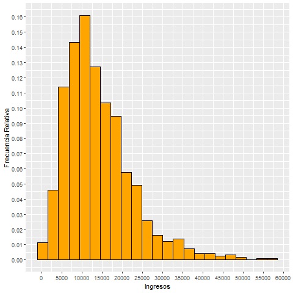

```python
%%R

ggplot(data = data_R, aes(x=ingresos ))+
geom_histogram(aes(y = after_stat(count / sum(count))) , breaks=L , fill="orange", color="black")+
 scale_y_continuous( n.breaks = 15 )+
  scale_x_continuous(n.breaks = 12)+
  labs(x = "Ingresos",y = "Frecuencia Relativa")
```

We add to the previous histogram associated vertical dashed lines to the values of some descriptive statistics :

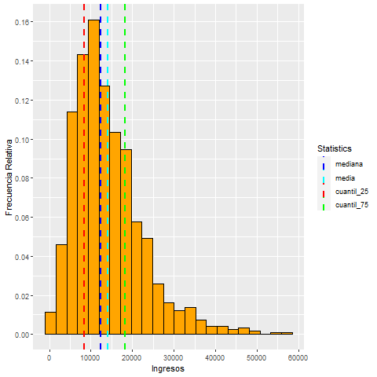

```python
%%R

ggplot(data = data_R, aes(x=ingresos ))+
geom_histogram(aes(y = after_stat(count / sum(count))) , breaks=L , fill="orange", color="black")+
 scale_y_continuous( n.breaks = 10 )+
  scale_x_continuous(n.breaks = 10)+
  labs(x = "Ingresos", y = "Frecuencia Relativa")+

  geom_vline(aes(xintercept = median(ingresos),
                  color = "mediana"),
              linetype = "dashed",
              size = 1) +
   geom_vline(aes(xintercept = mean(ingresos),
                  color = "media"),
              linetype = "dashed",
              size = 1) +
   geom_vline(
     aes(xintercept = quantile(ingresos, 0.25),
         color = "cuantil_25"),
     linetype = "dashed",
     size = 1
   ) +
   geom_vline(
     aes(xintercept = quantile(ingresos, 0.75),
         color = "cuantil_75"),
     linetype = "dashed",
     size = 1
   ) +
    scale_color_manual(
     name = "Statistics",
     values = c(
       mediana = "blue",
       media = "cyan",
       cuantil_25 = "red",
       cuantil_75 = "green"

     )
   )
```

### Histogram in Python:

```python
 # pip install plotnine
```

```python
from plotnine import ggplot, aes, geom_line, geom_point, geom_histogram, geom_bar, geom_boxplot, scale_y_continuous, scale_x_continuous, labs, after_stat,  geom_vline, scale_color_manual, theme_gray, theme_xkcd, scale_color_identity, geom_hline, facet_wrap, scale_fill_discrete, scale_fill_manual,  scale_fill_hue, guides, guide_legend
from mizani.formatters import percent_format
```

We generate a histogram of the quantitative variable *income* using the categorization intervals obtained with Scott's rule :

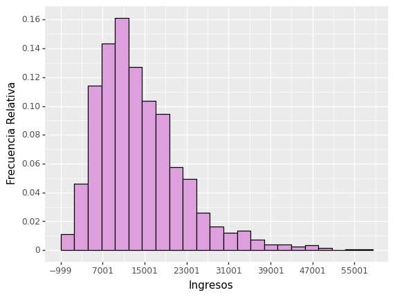

```python
(
ggplot( data_Python )
+  aes(x='ingresos' , y =  after_stat('width*density'))
+ geom_histogram(breaks=L , fill="plum", color="black")
+  labs(x = "Ingresos", y = "Frecuencia Relativa")
+ scale_x_continuous( breaks = range(int(data_Python['ingresos'].min()) , int(data_Python['ingresos'].max()) , 8000) )
+ scale_y_continuous( breaks = np.arange(0, 0.17, 0.02) )
)
```

We add to the previous histogram associated vertical dashed lines to the values of some descriptive statistics :

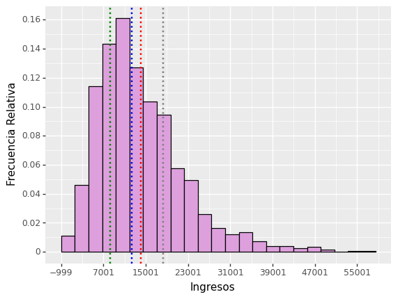

```python
(
ggplot( data_Python )
+  aes(x='ingresos' , y =  after_stat('width*density'))
+ geom_histogram(breaks=L , fill="plum", color="black")
+  labs(x = "Ingresos", y = "Frecuencia Relativa")
+ scale_x_continuous( breaks = range(int(data_Python['ingresos'].min()) , int(data_Python['ingresos'].max()) , 8000) )
+ scale_y_continuous( breaks = np.arange(0, 0.17, 0.02) )

+  geom_vline( xintercept=[data_Python['ingresos'].mean(), data_Python['ingresos'].median() , np.quantile( data_Python[['ingresos']] , 0.25), np.quantile( data_Python[['ingresos']] , 0.75)],
                 color=['red','blue','green', 'gray'],     # add colour
                 size=[1,1,1,1],                          # set line thickness
                 linetype='dotted',
                 show_legend = True    # set line type

                )

)
```

We can add a legend as follows :

```python
df = pd.DataFrame({'statistics': ['mean', 'median','Q25', 'Q75' ] ,
                   'value' : [ data_Python['ingresos'].mean(), data_Python['ingresos'].median() , np.quantile( data_Python[['ingresos']] , 0.25), np.quantile( data_Python[['ingresos']] , 0.75) ]
                   })

df
```

|  | statistics | value |
| --- | --- | --- |
| 0 | mean | 14078.766909 |
| 1 | median | 12331.000000 |
| 2 | Q25 | 8310.600000 |
| 3 | Q75 | 18269.375000 |

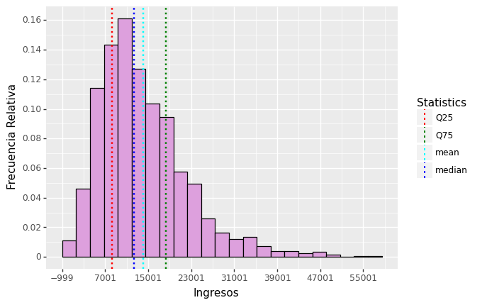

```python
p = (
ggplot( data_Python )
+  aes(x='ingresos' , y =  after_stat('width*density'))
+ geom_histogram(breaks=L , fill="plum", color="black")
+  labs(x = "Ingresos", y = "Frecuencia Relativa")
+ scale_x_continuous( breaks = range(int(data_Python['ingresos'].min()) , int(data_Python['ingresos'].max()) , 8000) )
+ scale_y_continuous( breaks = np.arange(0, 0.17, 0.02) )

+  geom_vline( df, aes(xintercept='value', color='statistics'), show_legend=True , linetype='dotted',size=[1,1,1,1])
+  scale_color_manual(
     name = "Statistics",
     values = [  "red",  "green", "cyan", "blue" ]
     )
)

p
```

We can save the image above in high quality as follows :

```python
p.save("myplot2.png", dpi=600, path="C:/Users/Usuario/Pictures")
```

## Bar Plot

A *bar plot* is an unstacked bar chart used to represent the absolute or relative frequencies of a variable categorical.

The bar chart is constructed as follows:

On the *x-axis* it contains the path of the categorical variable. In the *y-axis* the absolute or relative frequencies of the intervals of categorization in the quantitative variable.

Inside the chart there are unstacked bars, as many as categories has the variable categorica, each bar is assigned to a category of the variable, and has a height equal to the frequency absolute or relative of the category in the categorical variable.

### Bar-plot in R

We generate a bar plot of the categorical variable *mineduc* (level of education):

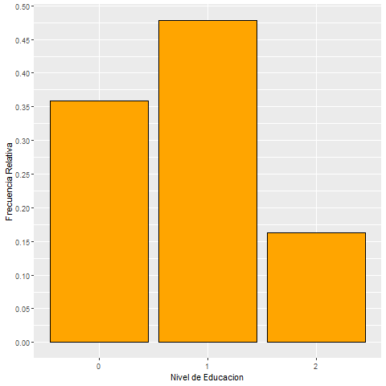

```python
%%R

ggplot(data = data_R, aes(x=neduc ))+
geom_bar(aes(y = after_stat(count / sum(count))) ,
 fill="orange", color="black")+
 scale_y_continuous( n.breaks = 15 )+
  labs(x = "Nivel de Educacion",
  y = "Frecuencia Relativa")
```

### Bar-plot in Python

We generate a bar plot of the categorical variable *mineduc* (level of education):

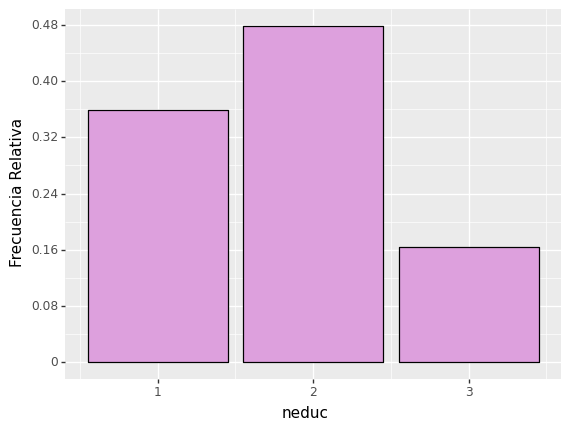

```python
(
ggplot( data_Python )
+  aes(x='neduc' , y =  after_stat('prop'))
+ geom_bar( fill="plum", color="black")
+  labs(x = "neduc", y = "Frecuencia Relativa")
+ scale_y_continuous( breaks = np.arange(0, 0.6, 0.08) )
)
```

## Box-Plot

The **box-plot** is a plot for quantitative variables that contains the following elements:

- The **left end of the box** (box) represents the value $Q(0.25, X_k)$
- The **right end of the box** represents the value $Q(0.75, X_k)$
- The **line inside the box** represents the value $Median(X_k)$
- The **left end of the horizontal line** is: $$ Max \left( Min(X_k) \hspace{0.1cm},\hspace{0.1cm} Q(0.25,X_k) - 1.5\cdot RIC \right) $$
- The **right end of the horizontal line** is:

$$ Min \left( Max(X_k) \hspace{0.1cm},\hspace{0.1cm} Q(0.75,X_k) + 1.5\cdot RIC \right) $$

- The points that are beyond the extreme left or right of the horizontal line are considered **outlier observations**.

Where: $\hspace{0.15cm} IQR= Q(0.75,X_k) - Q(0.25,X_k)$ is the **interquartile range** of $X_k$.

### Box-plot in R

We generate a box-plot of the quantitative variable *income*

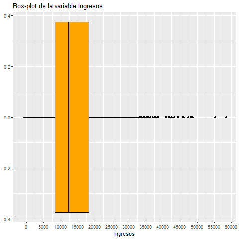

```python
%%R

ggplot(data_R) +
  geom_boxplot( aes(x = ingresos), fill="orange",
  color = 'black') +
  xlab("Ingresos") +
  ggtitle("Box-plot de la variable Ingresos ")+
  scale_x_continuous(n.breaks = 12)
```

We add dashed vertical lines with relevant values on the previous chart :

```python
%%R

 rango_intercuartilico_ingresos<-quantile(data_R$ingresos, 0.75) - quantile(data_R$ingresos, 0.25)

extremo_izquierdo<- max( min(data_R$ingresos) ,  quantile(data_R$ingresos, 0.25) - 1.5*rango_intercuartilico_ingresos)
extremo_derecho<- min( max(data_R$ingresos) ,  quantile(data_R$ingresos, 0.75) + 1.5*rango_intercuartilico_ingresos)
```

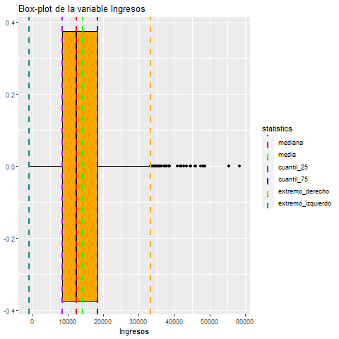

```python
%%R

ggplot(data_R) +
  geom_boxplot( aes(x = ingresos), fill="orange", color = 'black') +
  xlab("Ingresos") +
  ggtitle("Box-plot de la variable Ingresos ")+
  scale_x_continuous(n.breaks = 8)+

 geom_vline(aes(xintercept = median(ingresos),
                  color = "mediana"),
              linetype = "dashed",
              size = 1) +
   geom_vline(aes(xintercept = mean(ingresos),
                  color = "media"),
              linetype = "dashed",
              size = 1) +
   geom_vline(
     aes(xintercept = quantile(ingresos, 0.25),
         color = "cuantil_25"),
     linetype = "dashed",
     size = 1
   ) +
   geom_vline(
     aes(xintercept = quantile(ingresos, 0.75),
         color = "cuantil_75"),
     linetype = "dashed",
     size = 1
   )   +
   geom_vline(
     aes(xintercept = extremo_izquierdo,
         color = "extremo_izquierdo"),
     linetype = "dashed",
     size = 1
   )   +
  geom_vline(
     aes(xintercept = extremo_derecho,
         color = "extremo_derecho"),
     linetype = "dashed",
     size = 1
   )  +
   scale_color_manual(
     name = "statistics",
     values = c(
       mediana = "red",
       media = "green",
       cuantil_25 = "purple",
       cuantil_75 = "blue",
       extremo_derecho="orange",
       extremo_izquierdo="cyan4"
     )
   )
```

### Box-plot in Python

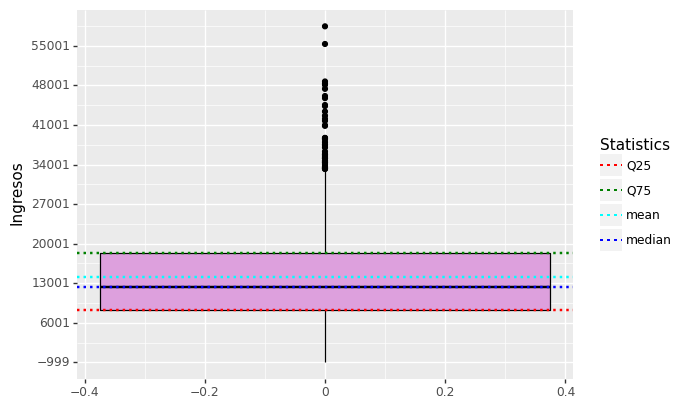

```python
(
ggplot( data_Python )
+  aes( x=list(range(0, 1 , len(data_Python))) , y = 'ingresos' )
+ geom_boxplot(fill="plum", color="black" )
+  labs(y = "Ingresos" )
+ scale_y_continuous( breaks = range(int(data_Python['ingresos'].min()) , int(data_Python['ingresos'].max()) , 7000) )
+  geom_hline( df, aes(yintercept='value', color='statistics'), show_legend=True , linetype='dotted',size=[1,1,1,1])
+  scale_color_manual(
     name = "Statistics",
     values = [  "red",  "green", "cyan", "blue" ]
     )
)
```

## Skewness and Kurtosis

### Skewness Coefficient

The Fisher's Skewness coefficient of the quantitative variable $X_k$ is:

$$ Skewness(X_k) = \dfrac{\overline{x_{k}}_{3}}{S(X_k)^{3}} $$

Where: $$ \overline{x_{k}}_{3}=\dfrac{1}{n}\sum_{i=1}^{n} (x_{ik})^{3} $$

#### Skewness coefficient properties

The **Fisher's skewness coefficient** measures the **degree of symmetry** of the distribution of the observations of a variable with respect to its arithmetic means.

- If $Skewness(X_k) > 0$ $\Rightarrow$ the distribution of $X_k$ is **asymmetric to the right**.
- If $Skewness(X_k) <0$ $\Rightarrow$ the distribution of $X_k$ is **asymmetric to the left**.
- If the distribution is **symmetric** about the means $\Rightarrow$ $Skewness(X_k)=0$ . But the converse is not true.

#### Skewness in R

```python
%%R

library(moments)
```

```python
%%R

skewness(data_R$ingresos)
```

```
[1] 1.304721
```

#### Skewness in Python

```python
import scipy
```

```python
scipy.stats.skew(data_Python['ingresos'])
```

```
1.304721100228902
```

#### Skewness Comparison in R

```python
%%R

set.seed(123)

X1 <- rchisq(5000, 2)

skewness(X1)
```

```
[1] 2.184111
```

```
R[write to console]: `stat_bin()` using `bins = 30`. Pick better value with `binwidth`.
```

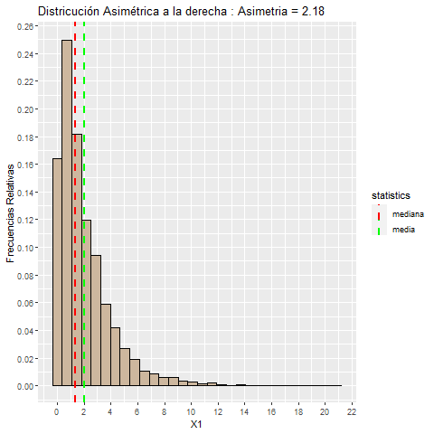

```python
%%R

p1<- ggplot(data = as.data.frame(X1), aes(x=X1 ))+
geom_histogram(aes(y = after_stat(count / sum(count)))   , fill="bisque3", color="black")+
 scale_y_continuous( n.breaks = 15 )+
  scale_x_continuous(n.breaks = 12)+
  xlab("X1") +
  ylab("Frecuencias Relativas") +
  ggtitle("Districución Asimétrica a la derecha : Asimetria = 2.18")+

 geom_vline(aes(xintercept = median(X1),
                  color = "mediana"),
              linetype = "dashed",
              size = 1) +
   geom_vline(aes(xintercept = mean(X1),
                  color = "media"),
              linetype = "dashed",
              size = 1)+

   scale_color_manual(
     name = "statistics",
     values = c(
       mediana = "red",
       media = "green"
     )
   )

p1
```

```python
%%R

set.seed(123)

X2 <- rnorm(5000, 2)

skewness(X2)
```

```
[1] 0.01169851
```

```
R[write to console]: `stat_bin()` using `bins = 30`. Pick better value with `binwidth`.
```

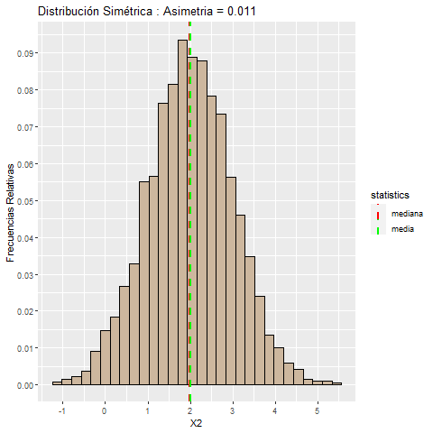

```python
%%R

p2<- ggplot(data = as.data.frame(X2), aes(x=X2))+
geom_histogram(aes(y = after_stat(count / sum(count)))   , fill="bisque3", color="black")+
 scale_y_continuous( n.breaks = 15 )+
  scale_x_continuous(n.breaks = 12)+
  xlab("X2") +
  ylab("Frecuencias Relativas") +
  ggtitle("Distribución Simétrica : Asimetria = 0.011")+

  geom_vline(aes(xintercept = median(X2),
                  color = "mediana"),
              linetype = "dashed",
              size = 1) +
   geom_vline(aes(xintercept = mean(X2),
                  color = "media"),
              linetype = "dashed",
              size = 1)+

   scale_color_manual(
     name = "statistics",
     values = c(
       mediana = "red",
       media = "green"
     )
   )

p2
```

```python
%%R

set.seed(123)

X3 <- rbeta(5000, 9, 2)

skewness(X3)
```

```
[1] -0.8586165
```

```
R[write to console]: `stat_bin()` using `bins = 30`. Pick better value with `binwidth`.
```

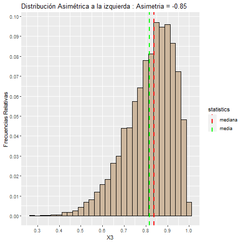

```python
%%R

p3<- ggplot(data = as.data.frame(X3), aes(x=X3))+
geom_histogram(aes(y = after_stat(count / sum(count)))   , fill="bisque3", color="black")+
 scale_y_continuous( n.breaks = 15 )+
  scale_x_continuous(n.breaks = 12)+
  xlab("X3") +
  ylab("Frecuencias Relativas") +
  ggtitle("Distribución Asimétrica a la izquierda : Asimetria = -0.85")+

  geom_vline(aes(xintercept = median(X3),
                  color = "mediana"),
              linetype = "dashed",
              size = 1) +
   geom_vline(aes(xintercept = mean(X3),
                  color = "media"),
              linetype = "dashed",
              size = 1)+

   scale_color_manual(
     name = "statistics",
     values = c(
       mediana = "red",
       media = "green"
     )
   )

p3
```

```
R[write to console]: `stat_bin()` using `bins = 30`. Pick better value with `binwidth`.
```

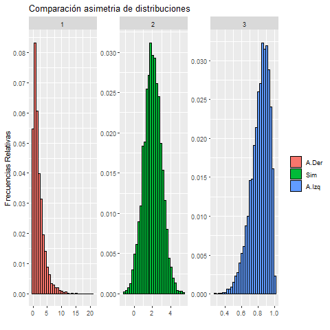

```python
%%R

df<-as.data.frame(cbind(c(X1,X2,X3), grupo=c(rep(1,5000), rep(2,5000),rep(3,5000))))

ggplot(data = df , aes(x=V1, fill=factor(grupo)))+
geom_histogram(aes(y = after_stat(count/sum(count))) , color="black")+
  facet_wrap(grupo~., scales="free", ncol = 3)+
 scale_y_continuous( n.breaks = 10 )+
  scale_x_continuous(n.breaks = 5)+
  ggtitle("Comparación asimetria de distribuciones")+
  ylab("Frecuencias Relativas")+ xlab("")+
  scale_fill_discrete(labels = c("A.Der", "Sim", "A.Izq"))+
  guides(fill = guide_legend(title = " "),
         colour = guide_legend(title = " "))
```

#### Skewness Comparsion in Python

```python
np.random.seed(123)

X1 = np.random.chisquare(df=2, size=5000)

scipy.stats.skew(X1)
```

```
1.946984446321499
```

```python
X1_df = pd.DataFrame({'X1': X1})
X1_df.head()
```

|  | X1 |
| --- | --- |
| 0 | 2.384544 |
| 1 | 0.674135 |
| 2 | 0.514568 |
| 3 | 1.602867 |
| 4 | 2.542142 |

```python
df = pd.DataFrame({'statistics': ['mean', 'median' ] ,
                   'value' : [ X1_df['X1'].mean(), X1_df['X1'].median()]
                   })

df
```

|  | statistics | value |
| --- | --- | --- |
| 0 | mean | 1.982775 |
| 1 | median | 1.393094 |

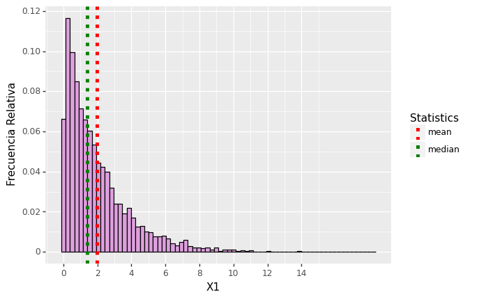

```python
(
ggplot( data=X1_df )
+ aes(x='X1' , y =  after_stat('width*density'))
+ geom_histogram( fill="plum", color="black")
+  labs(x = "X1", y = "Frecuencia Relativa")
+ scale_x_continuous( breaks = np.arange(0, 15, 2) )
+ scale_y_continuous( breaks = np.arange(0, 0.13, 0.02) )

+  geom_vline( df, aes(xintercept='value', color='statistics'), show_legend=True , linetype='dotted',size=[2,2])
+  scale_color_manual(
     name = "Statistics",
     values = [  "red",  "green"]
     )
)
```

```python
np.random.seed(123)

X2 = np.random.normal(0, 1, 5000)

scipy.stats.skew(X2)
```

```
-0.03708351858937471
```

```python
X2_df = pd.DataFrame({'X2': X2})
X2_df.head()
```

|  | X2 |
| --- | --- |
| 0 | -1.085631 |
| 1 | 0.997345 |
| 2 | 0.282978 |
| 3 | -1.506295 |
| 4 | -0.578600 |

```python
df = pd.DataFrame({'statistics': ['mean', 'median' ] ,
                   'value' : [ X2_df['X2'].mean(), X2_df['X2'].median()]
                   })

df
```

|  | statistics | value |
| --- | --- | --- |
| 0 | mean | 0.021083 |
| 1 | median | 0.029560 |

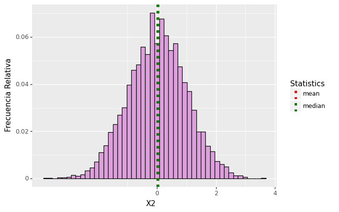

```python
(
ggplot( data=X2_df )
+ aes(x='X2' , y =  after_stat('width*density'))
+ geom_histogram( fill="plum", color="black")
+  labs(x = "X2", y = "Frecuencia Relativa")
+ scale_x_continuous( breaks = np.arange(0, 15, 2) )
+ scale_y_continuous( breaks = np.arange(0, 0.13, 0.02) )

+  geom_vline( df, aes(xintercept='value', color='statistics'), show_legend=True , linetype='dotted',size=[2,2])
+  scale_color_manual(
     name = "Statistics",
     values = [  "red",  "green"]
     )
)
```

```python
np.random.seed(123)

X3 = np.random.beta(9, 2, size=5000)

scipy.stats.skew(X3)
```

```
-0.8596198677550896
```

```python
X3_df = pd.DataFrame({'X3': X3})
X3_df.head()
```

|  | X3 |
| --- | --- |
| 0 | 0.638248 |
| 1 | 0.593855 |
| 2 | 0.738268 |
| 3 | 0.815022 |
| 4 | 0.864218 |

```python
df = pd.DataFrame({'statistics': ['mean', 'median' ] ,
                   'value' : [ X3_df['X3'].mean(), X3_df['X3'].median()]
                   })

df
```

|  | statistics | value |
| --- | --- | --- |
| 0 | mean | 0.818823 |
| 1 | median | 0.836811 |

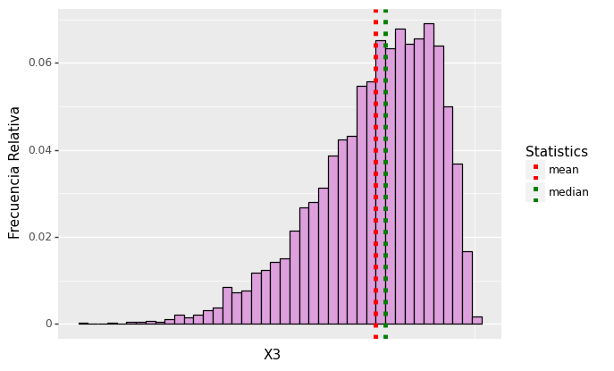

```python
(
ggplot( data=X3_df )
+ aes(x='X3' , y =  after_stat('width*density'))
+ geom_histogram( fill="plum", color="black")
+  labs(x = "X3", y = "Frecuencia Relativa")
+ scale_x_continuous( breaks = np.arange(0, 15, 2) )
+ scale_y_continuous( breaks = np.arange(0, 0.13, 0.02) )

+  geom_vline( df, aes(xintercept='value', color='statistics'), show_legend=True , linetype='dotted',size=[2,2])
+  scale_color_manual(
     name = "Statistics",
     values = [  "red",  "green"]
     )
)
```

```python
X1_df = X1_df >> rename(X=X.X1)
X2_df = X2_df >> rename(X=X.X2)
X3_df = X3_df >> rename(X=X.X3)
```

```python
df_X1_X2_X3 = concat([X1_df, X2_df, X3_df])
df_X1_X2_X3
```

|  | X |
| --- | --- |
| 0 | 2.384544 |
| 1 | 0.674135 |
| 2 | 0.514568 |
| 3 | 1.602867 |
| 4 | 2.542142 |
| ... | ... |
| 4995 | 0.938913 |
| 4996 | 0.750584 |
| 4997 | 0.946754 |
| 4998 | 0.899207 |
| 4999 | 0.928303 |

15000 rows × 1 columns

```python
import array as arr
```

```python
repeat_one = pd.DataFrame( arr.array('i',(1 for i in range(0,len(X1_df)))) )
```

```python
repeat_two = pd.DataFrame( arr.array('i',(2 for i in range(0,len(X2_df)))) )
```

```python
repeat_three = pd.DataFrame( arr.array('i',(3 for i in range(0,len(X3_df)))) )
```

```python
repeat_df = concat([repeat_one, repeat_two, repeat_three])
```

```python
repeat_df = repeat_df >> rename(group = X[0])
```

```python
repeat_df
```

|  | group |
| --- | --- |
| 0 | 1 |
| 1 | 1 |
| 2 | 1 |
| 3 | 1 |
| 4 | 1 |
| ... | ... |
| 4995 | 3 |
| 4996 | 3 |
| 4997 | 3 |
| 4998 | 3 |
| 4999 | 3 |

15000 rows × 1 columns

```python
df_final = concat([df_X1_X2_X3 , repeat_df], axis=1)
```

```python
df_final
```

|  | X | group |
| --- | --- | --- |
| 0 | 2.384544 | 1 |
| 1 | 0.674135 | 1 |
| 2 | 0.514568 | 1 |
| 3 | 1.602867 | 1 |
| 4 | 2.542142 | 1 |
| ... | ... | ... |
| 4995 | 0.938913 | 3 |
| 4996 | 0.750584 | 3 |
| 4997 | 0.946754 | 3 |
| 4998 | 0.899207 | 3 |
| 4999 | 0.928303 | 3 |

15000 rows × 2 columns

```python
df_final['group'] = df_final['group'].astype('category')
```

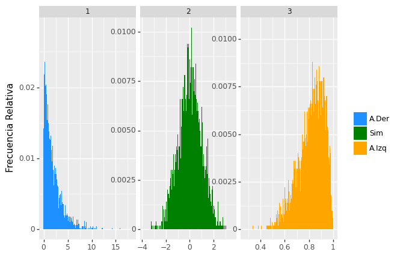

```python
(
ggplot( data=df_final )
+ aes(x='X' , y =  after_stat('width*density'), fill='group' )
+ geom_histogram(  )
+ labs(x = " ", y = "Frecuencia Relativa")
+ facet_wrap('group', scales="free", ncol = 3 )
+ scale_fill_manual(values=["dodgerblue","green","orange"] , labels=["A.Der", "Sim", "A.Izq"]  )
+ guides(fill = guide_legend(title = " "),
         colour = guide_legend(title = " "))
)
```

## Kurtosis Coefficient

The **kurtosis coefficient** of the quantitative variable $X_k$ is:

$$ Kurtosis(X_k) = \dfrac{\overline{x_k}_{4}}{S(X_k)^{4}} $$

Where:

\begin{gather*} \overline{x_k}_{4}=\dfrac{1}{n}\sum_{i=1}^{n} (X_i)^{4} \end{gather*}

### Kurtosis coefficient properties

The **coefficient of kurtosis** primarily measures the **degree of pointing** of the distribution of the observations of a variable.

- If $Kurtosis(X_k) > 3$ $\Rightarrow$ the distribution of $X_k$ is **more pointed** and with thicker tails **than the distribution normal**.
- If $Kurtosis(X_k) < 3$ $\Rightarrow$ the distribution of $X_k$ is **less pointed** and with thinner tails **than the distribution normal**.

### Kurtosis in R

```python
%%R

kurtosis(data_R$ingresos)
```

```
[1] 5.630726
```

### Kurtosis in Python

```python
scipy.stats.kurtosis(data_Python['ingresos'], fisher=False)
```

```
5.630725909373049
```

#### Pointing Comparison in R

```python
%%R

set.seed(123)

X4<- rnorm(5000, 0, 2)

X5<-rnorm(5000, 0 , 1)
```

```
R[write to console]: `stat_bin()` using `bins = 30`. Pick better value with `binwidth`.
```

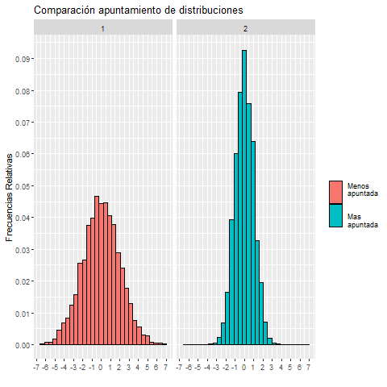

```python
%%R

 df<-as.data.frame(cbind(c(X4,X5), grupo=c(rep(1,5000), rep(2,5000))))


ggplot(data = df , aes(x=V1, fill=factor(grupo)))+
geom_histogram(aes(y = after_stat(count / sum(count))) , color="black")+
  facet_wrap(grupo~.)+
 scale_y_continuous( n.breaks = 15 )+
  scale_x_continuous(n.breaks = 12)+
  ggtitle("Comparación apuntamiento de distribuciones")+
   scale_fill_discrete(labels = c("Menos \napuntada\n", "\nMas \napuntada"))+
  guides(fill = guide_legend(title = " "),
         colour = guide_legend(title = " "))+
  xlab("")+
  ylab("Frecuencias Relativas")
```

#### Pointing Comparison in Python

```python
np.random.seed(123)

X1 = np.random.normal(0, 2, 5000)
X2 = np.random.normal(0, 1, 5000)

X1_df = pd.DataFrame({'X': X1})
X2_df = pd.DataFrame({'X': X2})

df_X1_X2 = concat([X1_df, X2_df])

repeat_one = pd.DataFrame( arr.array('i',(1 for i in range(0,len(X1_df)))) )
repeat_two = pd.DataFrame( arr.array('i',(2 for i in range(0,len(X2_df)))) )
repeat_df = concat([repeat_one, repeat_two])
repeat_df = repeat_df >> rename(group = X[0])

df_final = concat([df_X1_X2 , repeat_df], axis=1)
df_final['group'] = df_final['group'].astype('category')
```

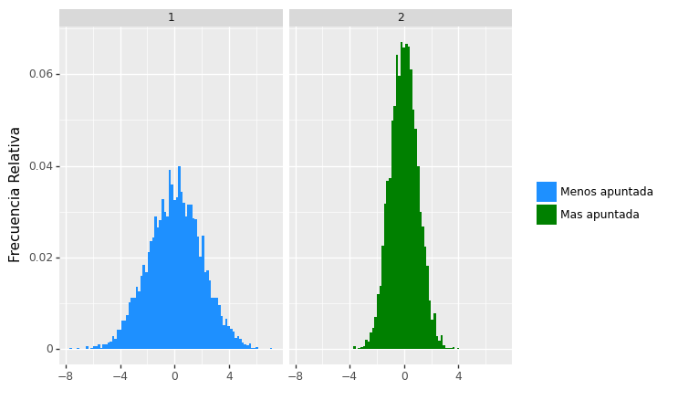

```python
(
ggplot( data=df_final )
+ aes(x='X' , y =  after_stat('width*density'), fill='group')
+ geom_histogram(  )
+ labs(x = " ", y = "Frecuencia Relativa")
+ facet_wrap('group',  ncol = 2 )
+ scale_fill_manual(values=["dodgerblue","green"] , labels=["Menos apuntada", "Mas apuntada"]  )
+ guides(fill = guide_legend(title = " "),
         colour = guide_legend(title = " "))
)
```